# Etapa 2 · Exploración descriptiva orientada al objetivo

**Estructura (consigna de la Etapa 2):**

1. Continuidad del proyecto
2. Dimensión del conjunto de datos y construcción de la base de la Etapa 2
3. Descripción de las variables
4. Herramientas de exploración descriptiva
5. Exploración descriptiva orientada al objetivo
6. Síntesis de hallazgos

# Configuración y paquetes

Se cargan los paquetes y se concentran en un solo chunk los parámetros que condicionan el análisis (ruta de la base, regla de días válidos, límites normativos), de modo que cualquier decisión se pueda cambiar sin tocar el resto del código.

- `tidyverse`: manipulación de datos y gráficos (`dplyr`, `tidyr`, `ggplot2`, `purrr`).
- `lubridate`: manejo de fechas.
- `scales` y `knitr`: formato de números y tablas.

**Código**

```r
library(tidyverse)
library(lubridate)
library(scales)
library(knitr)

theme_set(theme_minimal(base_size = 11))
options(knitr.kable.NA = "")   # las celdas NA de las tablas se muestran vacías
set.seed(2026)
dir.create("salidas", showWarnings = FALSE)

# ---- Parámetros ----------------------------------------------------------
ruta_base_e1   <- "salidas/datos_modelo.rds"  # base final de la Etapa 1
min_horas_dia  <- 18    # horas válidas mínimas (75 % de 24) para aceptar un promedio diario
min_dias_mes   <- 20    # días válidos mínimos para aceptar un promedio estación-mes
min_dias_anio  <- 274   # días válidos mínimos (75 % de 365) para aceptar un promedio anual
anios_comunes  <- 2021:2023  # años con todas las estaciones completas (ver 5.1)


meses_es <- c("Ene", "Feb", "Mar", "Abr", "May", "Jun", "Jul", "Ago", "Sep", "Oct", "Nov", "Dic")
```

## Límites de referencia (NOM-025-SSA1 y OMS)

Los límites de la NOM-025-SSA1-2021 no son un valor único: la norma establece un **cumplimiento gradual** (Secretaría de Salud, 2021). Para los años del análisis (2020-2025) se usan estos valores por año:

- 2020-2021: valores de la NOM-025-SSA1-2014 (24 h: PM10 = 75, PM2.5 = 45; anual: PM10 = 40, PM2.5 = 12), que la propia NOM-2021 menciona como la norma que sustituye (Secretaría de Salud, 2021).
- 2022-2023: primera etapa de la NOM-2021 (24 h: PM10 = 70, PM2.5 = 41; anual: PM10 = 36, PM2.5 = 10).
- 2024-2025: segunda etapa (24 h: PM10 = 60, PM2.5 = 33; anual: PM10 = 28, PM2.5 = 10).
- Los valores 25 / 50 µg/m³ (24 h) y 10 / 20 µg/m³ (anual) que aparecen en el reporte de la Etapa 1 corresponden a la **tercera etapa, vigente desde 2026**; no aplican a 2020-2025 y se usan aquí solo como referencia “meta”.
- Guías de la OMS 2021: PM2.5 = 15 (24 h) y 5 (anual); PM10 = 45 (24 h) y 15 (anual) (World Health Organization, 2021).

**Código**

```r
lim_norma <- tribble(
  ~anio, ~PM25_24h, ~PM10_24h, ~PM25_anual, ~PM10_anual, ~marco,
  2020,  45,        75,        12,          40,          "NOM-025-SSA1-2014",
  2021,  45,        75,        12,          40,          "NOM-025-SSA1-2014",
  2022,  41,        70,        10,          36,          "NOM-025-SSA1-2021, etapa 1",
  2023,  41,        70,        10,          36,          "NOM-025-SSA1-2021, etapa 1",
  2024,  33,        60,        10,          28,          "NOM-025-SSA1-2021, etapa 2",
  2025,  33,        60,        10,          28,          "NOM-025-SSA1-2021, etapa 2"
)
lim_oms <- c(PM25_24h = 15, PM10_24h = 45, PM25_anual = 5, PM10_anual = 15)
kable(lim_norma, caption = "Límites de la NOM-025-SSA1 aplicables por año (µg/m³)")
```

Límites de la NOM-025-SSA1 aplicables por año (µg/m³)

| anio | PM25_24h | PM10_24h | PM25_anual | PM10_anual | marco |
| --- | --- | --- | --- | --- | --- |
| 2020 | 45 | 75 | 12 | 40 | NOM-025-SSA1-2014 |
| 2021 | 45 | 75 | 12 | 40 | NOM-025-SSA1-2014 |
| 2022 | 41 | 70 | 10 | 36 | NOM-025-SSA1-2021, etapa 1 |
| 2023 | 41 | 70 | 10 | 36 | NOM-025-SSA1-2021, etapa 1 |
| 2024 | 33 | 60 | 10 | 28 | NOM-025-SSA1-2021, etapa 2 |
| 2025 | 33 | 60 | 10 | 28 | NOM-025-SSA1-2021, etapa 2 |

# 1 Continuidad del proyecto

**Objetivo de indagación.** Identificar en qué estaciones de monitoreo del SIMA (y, con ello, en qué zonas del Área Metropolitana de Monterrey, AMM) y en qué meses del año la exposición a PM2.5 y PM10 es menor y mayor. Para ello se estimará, por estación y mes, el nivel típico del promedio diario (mediana y media) y la proporción de días que rebasan los límites de referencia, y se contrastará si las diferencias entre estaciones y entre meses son estadísticamente significativas considerando la dependencia temporal de los datos, con el fin de orientar dónde y cuándo la calidad del aire es más favorable para vivir.

**Objetivos específicos.**

1. Caracterizar el nivel y la variabilidad de PM2.5 y PM10 en cada estación y agrupar las estaciones con perfiles anuales de exposición similares.
2. Determinar en qué meses se concentran los niveles más altos y más bajos, si ese patrón es común a todas las estaciones y si las diferencias entre estaciones y meses son significativas.
3. Cuantificar, con intervalos de confianza, con qué frecuencia y en qué épocas cada estación rebasa los límites de referencia.
4. Identificar las condiciones meteorológicas y de otros contaminantes asociadas a los días de mayor concentración y a los días críticos.
- Respecto a la Etapa 1, el objetivo separa **qué se quiere saber** de **cómo se hará** (agrupar, contrastar), y cambia la unidad de comparación de zona a estación y el periodo de comparación a 2021-2023 (secciones 5.1 y 5.4).
- **Retroalimentación de la Etapa 1 y cómo se atiende aquí:** (i) documentación sistemática de las variables (tipo, unidad, rango, faltantes e imputados; sección 3.1); (ii) trazabilidad del número de filas de la base final, con la conciliación de la sección 2.1; (iii) decisión sobre valores extremos por variable (ver notas de la sección 3.1: se winsorizaron todas las variables salvo `PM25`, que solo se marcó); (iv) corrección de los límites normativos (25 y 50 µg/m³ son de 2026).

# 2 Dimensión del conjunto de datos y base de la Etapa 2

## 2.1 Importación de la base final de la Etapa 1

Se lee el archivo `datos_modelo.rds` generado al final de la Etapa 1 (limpia, imputada, con atributos derivados y escalada). Se verifica que existan las columnas que se usarán y se reporta su dimensión.

**Código**

```r
base_e1 <- readRDS(ruta_base_e1)

tibble(
  Elemento = c("Registros (estación-hora)", "Columnas", "Estaciones", "Inicio", "Fin"),
  Valor = c(comma(nrow(base_e1)), ncol(base_e1), n_distinct(base_e1$estacion),
            format(min(base_e1$fecha), "%Y-%m-%d"), format(max(base_e1$fecha), "%Y-%m-%d"))
) |> kable(caption = "Dimensión de la base final de la Etapa 1")
```

Dimensión de la base final de la Etapa 1

| Elemento | Valor |
| --- | --- |
| Registros (estación-hora) | 552,503 |
| Columnas | 131 |
| Estaciones | 13 |
| Inicio | 2020-01-02 |
| Fin | 2025-12-31 |

### 2.1.1 Conciliación con la Etapa 1

La Etapa 1 reportó una base de modelado sin NO3 (historial corto, solo 2024-2025). El archivo `datos_modelo.rds` sí la incluye. Se desglosa el total para que cualquiera pueda reproducir de dónde salen las filas, cuántas son de entrenamiento y de prueba, y por qué la base inicia el 2 de enero de 2020.

**Código**

```r
tibble(Elemento = c("Base final Etapa 1 (con NO3)", "Horas de NO3", "Base sin NO3"),
       Valor = c(nrow(base_e1), sum(base_e1$estacion == "NO3"), sum(base_e1$estacion != "NO3"))) |>
  kable(format.args = list(big.mark = ","), caption = "Conciliación con la base reportada en la Etapa 1")
```

Conciliación con la base reportada en la Etapa 1

| Elemento | Valor |
| --- | --- |
| Base final Etapa 1 (con NO3) | 552,503 |
| Horas de NO3 | 17,520 |
| Base sin NO3 | 534,983 |

**Código**

```r
base_e1 |> count(NO3 = estacion == "NO3", conjunto) |>
  kable(format.args = list(big.mark = ","), caption = "Registros por conjunto, con y sin NO3")
```

Registros por conjunto, con y sin NO3

| NO3 | conjunto | n |
| --- | --- | --- |
| FALSE | entrenamiento | 461,762 |
| FALSE | prueba | 73,221 |
| TRUE | entrenamiento | 8,760 |
| TRUE | prueba | 8,760 |

**Código**

```r
# ¿Por qué inicia el 2 de enero de 2020?
base_e1 |> group_by(estacion) |>
  summarise(inicio = min(fecha), fin = max(fecha), .groups = "drop") |>
  arrange(inicio) |> kable(caption = "Primer y último registro por estación")
```

Primer y último registro por estación

| estacion | inicio | fin |
| --- | --- | --- |
| CE | 2020-01-02 00:00:00 | 2025-12-31 23:00:00 |
| NO2 | 2020-01-02 00:00:00 | 2025-12-31 23:00:00 |
| NTE2 | 2020-01-02 00:00:00 | 2025-12-31 23:00:00 |
| SE3 | 2020-01-02 00:00:00 | 2025-12-31 23:00:00 |
| SO | 2020-01-02 00:00:00 | 2025-10-15 10:00:00 |
| SO2 | 2020-01-02 14:00:00 | 2025-12-31 23:00:00 |
| NE2 | 2021-01-01 00:00:00 | 2024-12-31 23:00:00 |
| SE | 2021-01-01 00:00:00 | 2025-12-31 23:00:00 |
| NE | 2021-01-01 05:00:00 | 2025-09-03 23:00:00 |
| NO | 2021-01-01 05:00:00 | 2024-07-15 23:00:00 |
| SE2 | 2021-01-01 05:00:00 | 2025-12-31 23:00:00 |
| SUR | 2021-01-01 05:00:00 | 2025-12-31 23:00:00 |
| NO3 | 2024-01-02 00:00:00 | 2025-12-31 23:00:00 |

## 2.2 Selección de variables para el análisis

No se necesitan las 131 columnas de la Etapa 1 (escaladas, dummies, rezagos). Se construye una base nueva solo con las variables que responden al objetivo:

| Grupo | Variables | Por qué se incluyen |
| --- | --- | --- |
| Objetivo | `PM25`, `PM10` | Son los contaminantes que definen “mejor para vivir” en el objetivo. |
| Meteorología | `TOUT`, `RH`, `WSR`, `RAINF`, `SR` | Explican la dispersión y la estacionalidad (inversiones térmicas en meses fríos, lluvia como remoción) (INECC, 2015; Molina et al., 2019). |
| Contexto de emisión | `NO2`, `CO` | Indicadores de combustión y tráfico; ayudan a interpretar de dónde viene el material particulado. |
| Identificación | `estacion`, `zona`, `msnm`, `fecha`, `anio`, `mes`, `hora`, `temporada`, `periodo_dia`, `dia_semana`, `es_fin_semana`, `conjunto`, `calidad_aire`, `PM25_24h` | Permiten comparar estaciones, zonas, meses y periodos. |
| Banderas | `imp_*`, `out_*` de las variables elegidas | Permiten auditar qué valores fueron imputados o marcados como extremos en la Etapa 1. |

No se incluyen por ahora: `O3` y `SO2` (otros objetivos del reto, no del nuestro), `NO` (redundante con NO2 para este fin), `PRS` (en esta red refleja sobre todo la altitud, que ya está en `msnm`) y `WDR` (circular y con la nota de convención del archivo de etiquetas por resolver; se retomará si el análisis lo requiere). La selección está en vectores para ampliarla fácilmente.

**Código**

```r
vars_pm   <- c("PM25", "PM10")
vars_met  <- c("TOUT", "RH", "WSR", "RAINF", "SR")
vars_ctx  <- c("NO2", "CO")
vars_sel  <- c(vars_pm, vars_met, vars_ctx)
vars_id   <- c("estacion", "zona", "msnm", "fecha", "anio", "mes", "hora", "temporada",
               "periodo_dia", "dia_semana", "es_fin_semana", "conjunto",
               "calidad_aire", "PM25_24h")

stopifnot(all(c(vars_id, vars_sel) %in% names(base_e1)))

datos_e2 <- base_e1 |>
  select(all_of(vars_id), all_of(vars_sel),
         any_of(paste0("imp_", vars_sel)), any_of(paste0("out_", vars_sel))) |>
  mutate(temporada = factor(temporada, c("invierno", "primavera", "verano", "otoño")),
         zona      = factor(zona),
         mes_lab   = factor(mes, 1:12, meses_es),
         .after = mes)

# Orden de las estaciones por PM2.5 medio (de la mejor a la peor), usado en todos los gráficos
ord_est <- datos_e2 |> filter(anio %in% anios_comunes) |> group_by(estacion) |>
  summarise(m = mean(PM25, na.rm = TRUE), .groups = "drop") |>
  arrange(m) |> pull(estacion) |> as.character()
# estaciones sin datos en el periodo común (p. ej. NO3) van al final, para no convertirlas en NA
ord_est <- c(ord_est, setdiff(unique(as.character(datos_e2$estacion)), ord_est))
datos_e2 <- datos_e2 |> mutate(estacion = factor(estacion, ord_est))

tibble(Base = c("Etapa 1 (final)", "Etapa 2 (horaria)"),
       Filas = c(nrow(base_e1), nrow(datos_e2)),
       Columnas = c(ncol(base_e1), ncol(datos_e2))) |>
  kable(format.args = list(big.mark = ","), caption = "Efecto de la selección de variables")
```

Efecto de la selección de variables

| Base | Filas | Columnas |
| --- | --- | --- |
| Etapa 1 (final) | 552,503 | 131 |
| Etapa 2 (horaria) | 552,503 | 40 |

## 2.3 Catálogo de estaciones (coordenadas)

Las coordenadas vienen de la tabla “Ubicación de estaciones de SIMA 2025” (Sistema Integral de Monitoreo Ambiental, 2025b); se convierten de grados-minutos-segundos a grados decimales para poder hacer mapas de puntos.

**Código**

```r
catalogo <- tribble(
  ~estacion, ~lat_g, ~lat_m, ~lat_s, ~lon_g, ~lon_m, ~lon_s,
  "SE",   25, 39, 55, 100, 14, 37,   "NE",   25, 44, 41, 100, 15, 11,
  "CE",   25, 40, 33, 100, 20, 18,   "NO",   25, 45, 46, 100, 22,  9,
  "SO",   25, 40, 32, 100, 27, 29,   "NO2",  25, 48,  1, 100, 35,  4,
  "NTE",  25, 47, 55, 100, 19, 38,   "NE2",  25, 46, 38, 100, 11, 17,
  "SE2",  25, 38, 45, 100,  5, 43,   "SO2",  25, 39, 54, 100, 24, 46,
  "SE3",  25, 36,  4,  99, 59, 57,   "SUR",  25, 37,  1, 100, 16, 26,
  "NTE2", 25, 43, 47, 100, 18, 36,   "NE3",  25, 47, 26, 100,  4, 42,
  "NO3",  25, 46,  6, 100, 27, 49
) |>
  mutate(lat = lat_g + lat_m / 60 + lat_s / 3600,
         lon = -(lon_g + lon_m / 60 + lon_s / 3600)) |>
  select(estacion, lat, lon)

stopifnot(all(as.character(unique(datos_e2$estacion)) %in% catalogo$estacion))
```

## 2.4 Base diaria

**Código**

```r
media_valida <- function(x) if (sum(!is.na(x)) >= min_horas_dia) mean(x, na.rm = TRUE) else NA_real_
suma_valida  <- function(x) if (sum(!is.na(x)) >= min_horas_dia) sum(x, na.rm = TRUE)  else NA_real_
max_valido   <- function(x) if (sum(!is.na(x)) >= min_horas_dia) max(x, na.rm = TRUE)  else NA_real_

datos_dia <- datos_e2 |>
  mutate(dia = as.Date(fecha)) |>
  group_by(estacion, zona, msnm, anio, mes, mes_lab, temporada, dia) |>
  summarise(
    n_horas   = n(),
    PM25      = media_valida(PM25), PM25_max = max_valido(PM25),
    PM10      = media_valida(PM10), PM10_max = max_valido(PM10),
    TOUT = media_valida(TOUT), RH = media_valida(RH), WSR = media_valida(WSR),
    SR   = media_valida(SR),   RAINF = suma_valida(RAINF),
    NO2  = media_valida(NO2),  CO = media_valida(CO),
    .groups = "drop") |>
   mutate(es_fin_semana = wday(dia, week_start = 1) >= 6)

# Base diaria del periodo común: se usa para comparar estaciones, zonas y meses
datos_dia_c <- datos_dia |> filter(anio %in% anios_comunes)

tibble(Elemento = c("Estación-días", "Estación-días con PM2.5 válido", "Estación-días con PM10 válido"),
       Valor = c(nrow(datos_dia), sum(!is.na(datos_dia$PM25)), sum(!is.na(datos_dia$PM10)))) |>
  kable(format.args = list(big.mark = ","), caption = "Dimensión de la base diaria")
```

Dimensión de la base diaria

| Elemento | Valor |
| --- | --- |
| Estación-días | 23,177 |
| Estación-días con PM2.5 válido | 22,930 |
| Estación-días con PM10 válido | 22,930 |

## 2.5 Guardado de las bases de la Etapa 2

**Código**

```r
saveRDS(datos_e2,  "salidas/etapa2_datos_horarios.rds")
saveRDS(datos_dia, "salidas/etapa2_datos_diarios.rds")
saveRDS(catalogo,  "salidas/etapa2_catalogo_estaciones.rds")
saveRDS(datos_dia_c, "salidas/etapa2_datos_diarios_comunes.rds")
readr::write_csv(datos_dia, "salidas/etapa2_datos_diarios.csv")
```

# 3 Descripción de las variables

## 3.1 Diccionario

Todas las variables de medición son cuantitativas continuas; las unidades son las del archivo de etiquetas del SIMA (Sistema Integral de Monitoreo Ambiental, 2025a). Las columnas `imp_` y `out_` son banderas lógicas (verdadero/falso).

**Código**

```r
dic_num <- tribble(
  ~variable, ~descripcion,                          ~tipo,                  ~unidad,
  "PM25",    "Partículas menores a 2.5 µm",         "Cuantitativa continua", "µg/m³",
  "PM10",    "Partículas menores a 10 µm",          "Cuantitativa continua", "µg/m³",
  "TOUT",    "Temperatura",                         "Cuantitativa continua", "°C",
  "RH",      "Humedad relativa",                    "Cuantitativa continua", "%",
  "WSR",     "Velocidad del viento",                "Cuantitativa continua", "km/h",
  "RAINF",   "Precipitación",                       "Cuantitativa continua", "mm/h",
  "SR",      "Radiación solar",                     "Cuantitativa continua", "kW/m²",
  "NO2",     "Dióxido de nitrógeno",                "Cuantitativa continua", "ppb",
  "CO",      "Monóxido de carbono",                 "Cuantitativa continua", "ppm",
  "msnm",    "Elevación de la estación",            "Cuantitativa continua", "m sobre el nivel del mar"
)

desc_num <- dic_num |>
  mutate(
    `% NA en la base` = map_dbl(variable, \(v) mean(is.na(datos_e2[[v]])) * 100),
    `% imputado`      = map_dbl(variable, \(v) if (paste0("imp_", v) %in% names(datos_e2)) mean(datos_e2[[paste0("imp_", v)]]) * 100 else NA_real_),
    `% extremo`       = map_dbl(variable, \(v) if (paste0("out_", v) %in% names(datos_e2)) mean(datos_e2[[paste0("out_", v)]]) * 100 else NA_real_),
    mín     = map_dbl(variable, \(v) min(datos_e2[[v]], na.rm = TRUE)),
    mediana = map_dbl(variable, \(v) median(datos_e2[[v]], na.rm = TRUE)),
    máx     = map_dbl(variable, \(v) max(datos_e2[[v]], na.rm = TRUE)))

kable(desc_num, digits = 2, caption = "Variables cuantitativas: tipo, unidad, faltantes y rango observado")
```

Variables cuantitativas: tipo, unidad, faltantes y rango observado

| variable | descripcion | tipo | unidad | % NA en la base | % imputado | % extremo | mín | mediana | máx |
| --- | --- | --- | --- | --- | --- | --- | --- | --- | --- |
| PM25 | Partículas menores a 2.5 µm | Cuantitativa continua | µg/m³ | 0 | 16.76 | 0.02 | 0.00 | 17.00 | 782.00 |
| PM10 | Partículas menores a 10 µm | Cuantitativa continua | µg/m³ | 0 | 3.92 | 0.08 | 1.61 | 51.00 | 811.00 |
| TOUT | Temperatura | Cuantitativa continua | °C | 0 | 3.72 | 0.00 | -6.30 | 23.95 | 44.63 |
| RH | Humedad relativa | Cuantitativa continua | % | 0 | 4.15 | 0.00 | 0.00 | 59.00 | 100.00 |
| WSR | Velocidad del viento | Cuantitativa continua | km/h | 0 | 3.90 | 0.00 | 0.10 | 7.40 | 63.30 |
| RAINF | Precipitación | Cuantitativa continua | mm/h | 0 | 2.38 |  | 0.00 | 0.00 | 74.00 |
| SR | Radiación solar | Cuantitativa continua | kW/m² | 0 | 2.87 |  | 0.00 | 0.01 | 1.25 |
| NO2 | Dióxido de nitrógeno | Cuantitativa continua | ppb | 0 | 9.27 | 0.00 | 0.00 | 11.50 | 188.60 |
| CO | Monóxido de carbono | Cuantitativa continua | ppm | 0 | 7.61 | 0.01 | 0.00 | 1.28 | 14.37 |
| msnm | Elevación de la estación | Cuantitativa continua | m sobre el nivel del mar | 0 |  |  | 334.00 | 555.00 | 702.00 |

Notas para interpretar la tabla:

- `% NA en la base` es 0 por construcción: la Etapa 1 descartó las filas con algún dato residual faltante. El faltante “original” está en `% imputado` (valores que no existían y fueron imputados en la Etapa 1) y en la sección de cobertura (horas que ya no están en la malla).
- `% extremo` es la proporción de valores marcados como extremos (3 × IQR) en la Etapa 1; esos valores se winsorizaron en todas las variables excepto `PM25` (solo se marcó). `SR` y `RAINF` no se marcaron (muchos ceros, IQR = 0).

**Código**

```r
dic_cat <- tribble(
  ~variable,       ~descripcion,                         ~tipo,                     ~categorias,
  "estacion",      "Estación de monitoreo del SIMA",     "Categórica nominal",      paste(n_distinct(datos_e2$estacion), "estaciones"),
  "zona",          "Zona geográfica de la estación",     "Categórica nominal",      paste(n_distinct(datos_e2$zona), "zonas"),
  "temporada",     "Estación del año (según mes)",       "Categórica ordinal",      "invierno, primavera, verano, otoño",
  "mes",           "Mes del año",                        "Ordinal cíclica",         "1 a 12",
  "hora",          "Hora del día (reloj local)",         "Ordinal cíclica",         "0 a 23",
  "periodo_dia",   "Madrugada / mañana / tarde / noche", "Categórica ordinal",      "4 periodos",
  "dia_semana",    "Día de la semana",                   "Categórica ordinal",      "lunes a domingo",
  "es_fin_semana", "Sábado o domingo",                   "Categórica binaria",      "verdadero / falso",
  "anio",          "Año calendario",                     "Discreta (ordinal)",      paste(min(datos_e2$anio), "a", max(datos_e2$anio)),
  "fecha",         "Fecha y hora de la medición",        "Fecha-hora",              "horaria"
)
kable(dic_cat, caption = "Variables categóricas y de tiempo")
```

Variables categóricas y de tiempo

| variable | descripcion | tipo | categorias |
| --- | --- | --- | --- |
| estacion | Estación de monitoreo del SIMA | Categórica nominal | 13 estaciones |
| zona | Zona geográfica de la estación | Categórica nominal | 7 zonas |
| temporada | Estación del año (según mes) | Categórica ordinal | invierno, primavera, verano, otoño |
| mes | Mes del año | Ordinal cíclica | 1 a 12 |
| hora | Hora del día (reloj local) | Ordinal cíclica | 0 a 23 |
| periodo_dia | Madrugada / mañana / tarde / noche | Categórica ordinal | 4 periodos |
| dia_semana | Día de la semana | Categórica ordinal | lunes a domingo |
| es_fin_semana | Sábado o domingo | Categórica binaria | verdadero / falso |
| anio | Año calendario | Discreta (ordinal) | 2020 a 2025 |
| fecha | Fecha y hora de la medición | Fecha-hora | horaria |

**Definición de temporada.** La temporada sigue las estaciones meteorológicas; la tabla se genera de los datos para verificar qué meses forman cada una.

**Código**

```r
datos_e2 |> distinct(mes, temporada) |> arrange(mes) |>
  group_by(temporada) |> summarise(meses = paste(meses_es[mes], collapse = ", "), .groups = "drop") |>
  kable(caption = "Definición de temporada")
```

Definición de temporada

| temporada | meses |
| --- | --- |
| invierno | Ene, Feb, Dic |
| primavera | Mar, Abr, May |
| verano | Jun, Jul, Ago |
| otoño | Sep, Oct, Nov |

## 3.2 Estadísticas descriptivas de las variables del análisis

La tabla de arriba solo da el rango horario. Como las variables meteorológicas, `NO2` y `CO` entrarán en la regresión, se calculan también la media, la desviación estándar y los cuartiles de sus **promedios diarios** en el periodo común 2021-2023 (la precipitación es la suma diaria, en mm/día). La columna `latex` sale lista para copiar en la Tabla 2 del reporte.

**Código**

```r
vars_tab2 <- c("PM25", "PM10", "TOUT", "RH", "WSR", "RAINF", "SR", "NO2", "CO")

est_diaria <- datos_dia_c |>
  summarise(across(all_of(vars_tab2),
                   list(media = \(x) mean(x, na.rm = TRUE), de = \(x) sd(x, na.rm = TRUE),
                        q1  = \(x) quantile(x, .25, na.rm = TRUE, names = FALSE),
                        med = \(x) median(x, na.rm = TRUE),
                        q3  = \(x) quantile(x, .75, na.rm = TRUE, names = FALSE)),
                   .names = "{.col}__{.fn}")) |>
  pivot_longer(everything(), names_to = c("variable", ".value"), names_sep = "__") |>
  mutate(f = if_else(variable %in% c("SR", "CO"), "%.2f", "%.1f"),
         latex = sprintf(paste0(f, " (", f, ") & ", f, " (", f, "--", f, ")"),
                         media, de, med, q1, q3)) |>
  select(-f)

kable(est_diaria, digits = 2,
      caption = "Estadísticas de los promedios diarios, 2021-2023 (RAINF: suma diaria, mm/día)")
```

Estadísticas de los promedios diarios, 2021-2023 (RAINF: suma diaria, mm/día)

| variable | media | de | q1 | med | q3 | latex |
| --- | --- | --- | --- | --- | --- | --- |
| PM25 | 20.51 | 10.82 | 13.10 | 18.16 | 25.25 | 20.5 (10.8) & 18.2 (13.1–25.3) |
| PM10 | 61.47 | 27.50 | 42.69 | 56.00 | 74.22 | 61.5 (27.5) & 56.0 (42.7–74.2) |
| TOUT | 23.13 | 6.34 | 18.96 | 24.40 | 28.18 | 23.1 (6.3) & 24.4 (19.0–28.2) |
| RH | 56.72 | 15.07 | 47.40 | 57.33 | 66.75 | 56.7 (15.1) & 57.3 (47.4–66.8) |
| WSR | 8.54 | 3.45 | 6.16 | 8.31 | 10.56 | 8.5 (3.5) & 8.3 (6.2–10.6) |
| RAINF | 0.39 | 7.73 | 0.00 | 0.00 | 0.00 | 0.4 (7.7) & 0.0 (0.0–0.0) |
| SR | 0.15 | 0.08 | 0.10 | 0.15 | 0.20 | 0.15 (0.08) & 0.15 (0.10–0.20) |
| NO2 | 15.32 | 8.83 | 9.01 | 13.18 | 19.49 | 15.3 (8.8) & 13.2 (9.0–19.5) |
| CO | 1.46 | 0.73 | 0.93 | 1.39 | 1.86 | 1.46 (0.73) & 1.39 (0.93–1.86) |

## 3.3 Valores que requieren revisión

Se buscan valores imposibles, inusuales o inconsistentes. En calidad del aire un valor muy alto puede ser un episodio real (por ejemplo, pirotecnia de fin de año) y no un error, por eso se **revisan y se reportan, no se eliminan** en esta etapa.

**Código**

```r
revision <- tibble(
  Revisión = c("PM2.5 horario > PM10 horario (físicamente inconsistente)",
               "PM2.5 horario > 300 µg/m³", "PM10 horario > 500 µg/m³",
              "Temperatura < 0 °C", "Humedad relativa = 100 %", "Humedad relativa < 5 % (implausible)",
               "Horas con precipitación > 0", "Velocidad del viento > 60 km/h"),
  Horas = c(sum(datos_e2$PM25 > datos_e2$PM10, na.rm = TRUE),
            sum(datos_e2$PM25 > 300, na.rm = TRUE), sum(datos_e2$PM10 > 500, na.rm = TRUE),
            sum(datos_e2$TOUT < 0, na.rm = TRUE), sum(datos_e2$RH >= 100, na.rm = TRUE),
            sum(datos_e2$RH < 5, na.rm = TRUE),
            sum(datos_e2$RAINF > 0, na.rm = TRUE), sum(datos_e2$WSR > 60, na.rm = TRUE))
) |> mutate(`% de las horas` = Horas / nrow(datos_e2) * 100)
kable(revision, digits = 3, format.args = list(big.mark = ","), caption = "Valores a revisar (base horaria)")
```

Valores a revisar (base horaria)

| Revisión | Horas | % de las horas |
| --- | --- | --- |
| PM2.5 horario > PM10 horario (físicamente inconsistente) | 58 | 0.010 |
| PM2.5 horario > 300 µg/m³ | 63 | 0.011 |
| PM10 horario > 500 µg/m³ | 263 | 0.048 |
| Temperatura < 0 °C | 959 | 0.174 |
| Humedad relativa = 100 % | 83 | 0.015 |
| Humedad relativa < 5 % (implausible) | 2,005 | 0.363 |
| Horas con precipitación > 0 | 7,950 | 1.439 |
| Velocidad del viento > 60 km/h | 3 | 0.001 |

**Código**

```r
# ¿Cuándo y dónde están los PM2.5 horarios más altos?
datos_e2 |> arrange(desc(PM25)) |>
    select(estacion, fecha, PM25, PM10, imp_PM25, imp_PM10) |> slice_head(n = 10) |>
  kable(digits = 1, caption = "Diez valores horarios más altos de PM2.5")
```

Diez valores horarios más altos de PM2.5

| estacion | fecha | PM25 | PM10 | imp_PM25 | imp_PM10 |
| --- | --- | --- | --- | --- | --- |
| SE2 | 2023-12-31 23:00:00 | 782 | 623.7 | FALSE | FALSE |
| NE | 2023-12-31 21:00:00 | 777 | 378.0 | FALSE | FALSE |
| NE | 2023-12-31 23:00:00 | 773 | 513.6 | FALSE | FALSE |
| NE | 2023-12-31 22:00:00 | 763 | 513.6 | FALSE | FALSE |
| NE | 2024-01-01 03:00:00 | 729 | 513.6 | FALSE | FALSE |
| NE | 2024-01-01 02:00:00 | 690 | 513.6 | FALSE | FALSE |
| SE2 | 2023-12-31 22:00:00 | 687 | 513.0 | FALSE | FALSE |
| NO | 2023-12-31 22:00:00 | 570 | 452.0 | FALSE | FALSE |
| NE | 2024-01-01 04:00:00 | 557 | 513.6 | FALSE | FALSE |
| SO | 2023-12-31 23:00:00 | 556 | 369.0 | FALSE | FALSE |

**Código**

```r
# ¿Se concentran en fechas específicas del año? (día-mes de las horas con PM2.5 > 100)
datos_e2 |> filter(PM25 > 100) |>
  count(`día-mes` = format(fecha, "%m-%d"), sort = TRUE) |> slice_head(n = 10) |>
  kable(caption = "Días del año con más horas de PM2.5 > 100 µg/m³")
```

Días del año con más horas de PM2.5 > 100 µg/m³

| día-mes | n |
| --- | --- |
| 01-01 | 152 |
| 12-31 | 68 |
| 12-25 | 65 |
| 03-19 | 45 |
| 12-08 | 37 |
| 01-18 | 33 |
| 01-22 | 33 |
| 01-28 | 30 |
| 12-24 | 30 |
| 01-14 | 29 |

**Código**

```r
imp_pct <- function(x, a, solo_comun = FALSE) {
  if (solo_comun) { x <- x[a %in% anios_comunes]; if (length(x) == 0) return(NA_real_) }
  mean(x) * 100
}
datos_e2 |>
  group_by(estacion) |>
  summarise(`% PM2.5 imputado (todos los años)` = imp_pct(imp_PM25, anio),
            `% PM2.5 imputado (2021-2023)`      = imp_pct(imp_PM25, anio, TRUE),
            `% PM10 imputado (2021-2023)`       = imp_pct(imp_PM10, anio, TRUE),
            .groups = "drop") |>
  kable(digits = 1, caption = "Porcentaje de horas imputadas en la Etapa 1, por estación")
```

Porcentaje de horas imputadas en la Etapa 1, por estación

| estacion | % PM2.5 imputado (todos los años) | % PM2.5 imputado (2021-2023) | % PM10 imputado (2021-2023) |
| --- | --- | --- | --- |
| SUR | 22.9 | 24.8 | 2.4 |
| SE3 | 12.4 | 9.6 | 4.3 |
| SE | 13.7 | 10.3 | 3.0 |
| SO2 | 13.5 | 9.6 | 4.3 |
| NO2 | 14.6 | 8.5 | 2.7 |
| NTE2 | 13.8 | 8.0 | 2.8 |
| NO | 35.2 | 30.3 | 6.8 |
| NE | 6.6 | 6.0 | 2.1 |
| NE2 | 17.3 | 9.4 | 4.0 |
| CE | 13.9 | 10.3 | 2.7 |
| SO | 9.5 | 6.2 | 2.9 |
| SE2 | 9.3 | 12.0 | 4.7 |
| NO3 | 79.8 |  |  |

# 4 Herramientas de exploración descriptiva

Cada herramienta se eligió para responder una pregunta concreta del objetivo. No se repiten representaciones que den la misma información (Johnson y Wichern, 2007).

**Código**

```r
tribble(
  ~Sección, ~Pregunta, ~Herramienta, ~Variables,
  "4.1", "¿Está balanceada la base y qué tan frecuentes son las categorías de calidad del aire?", "Frecuencias, porcentajes, diagramas de barras", "estacion, zona, temporada, calidad_aire",
  "5.1", "¿Qué tan comparables son las estaciones (cobertura)?", "Mapa de calor de cobertura estación-año", "PM25, estacion, anio",
  "5.2", "¿Cómo se distribuyen PM2.5 y PM10? ¿Hay extremos?", "Medidas de resumen, histograma (log), regla de Tukey", "PM25, PM10",
  "5.3", "¿Se mueven juntos PM2.5 y PM10? ¿Qué fracción es fina?", "Dispersión, correlación Pearson/Spearman, razón PM2.5/PM10", "PM25, PM10",
  "5.4", "¿Qué estaciones y zonas tienen más PM?", "Diagramas de caja, tabla por estación/zona, mapa de puntos", "PM25, PM10, estacion, zona",
  "5.5", "¿Qué pesa más: estación, zona, mes o año?", "R² de modelos de un factor (descomposición de variabilidad)", "log(PM), estacion, zona, mes, anio",
  "5.6", "¿Qué meses son mejores/peores y es igual en todas las estaciones?", "Mapa de calor estación × mes, perfil relativo", "PM25, PM10, mes",
  "5.7", "¿Es estable el patrón entre años?", "Promedio anual por estación vs. límite anual", "PM25, PM10, anio",
  "5.8", "¿Con qué frecuencia se excede la norma y cuándo?", "% de días sobre límites NOM y OMS", "PM25, PM10, mes, estacion",
  "5.9", "¿Qué clima acompaña los meses altos?", "Ciclo anual del clima, correlación Spearman, dispersión con suavizado", "PM, TOUT, RH, WSR, RAINF, SR, NO2, CO",
  "5.10", "¿Influye la elevación?", "Dispersión estación vs. msnm", "PM, msnm",
  "5.11", "¿Cómo se ve el ciclo diario?", "Perfil horario por temporada", "PM25, PM10, hora, temporada",
  "5.12", "¿Cuándo y dónde hay más horas de calidad mala? ¿Cambia entre semana y fin de semana?", "Tablas cruzadas, V de Cramér", "calidad_aire, temporada, zona, es_fin_semana"
) |> kable(caption = "Mapa pregunta → herramienta")
```

Mapa pregunta → herramienta

| Sección | Pregunta | Herramienta | Variables |
| --- | --- | --- | --- |
| 4.1 | ¿Está balanceada la base y qué tan frecuentes son las categorías de calidad del aire? | Frecuencias, porcentajes, diagramas de barras | estacion, zona, temporada, calidad_aire |
| 5.1 | ¿Qué tan comparables son las estaciones (cobertura)? | Mapa de calor de cobertura estación-año | PM25, estacion, anio |
| 5.2 | ¿Cómo se distribuyen PM2.5 y PM10? ¿Hay extremos? | Medidas de resumen, histograma (log), regla de Tukey | PM25, PM10 |
| 5.3 | ¿Se mueven juntos PM2.5 y PM10? ¿Qué fracción es fina? | Dispersión, correlación Pearson/Spearman, razón PM2.5/PM10 | PM25, PM10 |
| 5.4 | ¿Qué estaciones y zonas tienen más PM? | Diagramas de caja, tabla por estación/zona, mapa de puntos | PM25, PM10, estacion, zona |
| 5.5 | ¿Qué pesa más: estación, zona, mes o año? | R² de modelos de un factor (descomposición de variabilidad) | log(PM), estacion, zona, mes, anio |
| 5.6 | ¿Qué meses son mejores/peores y es igual en todas las estaciones? | Mapa de calor estación × mes, perfil relativo | PM25, PM10, mes |
| 5.7 | ¿Es estable el patrón entre años? | Promedio anual por estación vs. límite anual | PM25, PM10, anio |
| 5.8 | ¿Con qué frecuencia se excede la norma y cuándo? | % de días sobre límites NOM y OMS | PM25, PM10, mes, estacion |
| 5.9 | ¿Qué clima acompaña los meses altos? | Ciclo anual del clima, correlación Spearman, dispersión con suavizado | PM, TOUT, RH, WSR, RAINF, SR, NO2, CO |
| 5.10 | ¿Influye la elevación? | Dispersión estación vs. msnm | PM, msnm |
| 5.11 | ¿Cómo se ve el ciclo diario? | Perfil horario por temporada | PM25, PM10, hora, temporada |
| 5.12 | ¿Cuándo y dónde hay más horas de calidad mala? ¿Cambia entre semana y fin de semana? | Tablas cruzadas, V de Cramér | calidad_aire, temporada, zona, es_fin_semana |

## 4.1 Variables categóricas: frecuencias y porcentajes

Para las variables categóricas (`estacion`, `zona`, `temporada`, `periodo_dia`, tipo de día y la categoría de calidad del aire) se calculan frecuencias y porcentajes por categoría, $\%_k = 100\, n_k / N$, donde $N$ es el número de registros estación-hora. El objetivo es doble: ver si la base está balanceada entre estaciones y zonas (lo que condiciona las comparaciones posteriores) y describir qué tan frecuentes son las categorías de calidad del aire.

**Código**

```r
ordenar <- function(x, orden) {
  x <- as.character(x)
  factor(x, levels = c(intersect(orden, unique(x)), setdiff(unique(x), orden)))
}

cat_base <- datos_e2 |>
  mutate(
    estacion     = factor(estacion, levels = levels(datos_e2$estacion)),
    zona         = as.character(zona),
    temporada    = ordenar(temporada, c("invierno", "primavera", "verano", "otoño")),
    periodo_dia  = ordenar(periodo_dia, c("madrugada", "mañana", "tarde", "noche")),
    fin_semana   = factor(if_else(as.logical(es_fin_semana), "Fin de semana", "Entre semana"),
                          levels = c("Entre semana", "Fin de semana")),
    calidad_aire = ordenar(str_to_sentence(as.character(calidad_aire)),
                           c("Buena", "Aceptable", "Mala", "Muy mala", "Extremadamente mala"))
  ) |>
    select(estacion, zona, anio, temporada, periodo_dia, fin_semana, calidad_aire, any_of("PM25_24h"))

frec <- function(d, var, nombre) {
  d |>
    count(categoria = .data[[var]], name = "n") |>
    mutate(variable = nombre, categoria = as.character(categoria), pct = n / sum(n) * 100) |>
    select(variable, categoria, n, pct)
}

est_zona <- cat_base |>
  distinct(estacion, zona) |>
  group_by(zona) |>
  summarise(estaciones = paste(sort(as.character(estacion)), collapse = ", "), .groups = "drop") |>
  mutate(variable = "Zona") |>
  rename(categoria = zona)

tab_cat <- bind_rows(
  frec(cat_base, "zona",         "Zona"),
  frec(cat_base, "estacion",     "Estación"),
  frec(cat_base, "temporada",    "Temporada"),
  frec(cat_base, "periodo_dia",  "Periodo del día"),
  frec(cat_base, "fin_semana",   "Tipo de día"),
  frec(cat_base, "calidad_aire", "Calidad del aire (categoría)")
) |>
  left_join(est_zona, by = c("variable", "categoria"))

kable(tab_cat, digits = 2, format.args = list(big.mark = ","),
      col.names = c("Variable", "Categoría", "Registros (horas)", "%", "Estaciones"),
      caption = "Frecuencias de las variables categóricas (unidad: estación-hora)")
```

Frecuencias de las variables categóricas (unidad: estación-hora)

| Variable | Categoría | Registros (horas) | % | Estaciones |
| --- | --- | --- | --- | --- |
| Zona | Centro | 52,314 | 9.47 | CE |
| Zona | Noreste | 70,769 | 12.81 | NE, NE2 |
| Zona | Noroeste | 100,404 | 18.17 | NO, NO2, NO3 |
| Zona | Norte | 51,691 | 9.36 | NTE2 |
| Zona | Sur | 43,819 | 7.93 | SUR |
| Zona | Sureste | 140,227 | 25.38 | SE, SE2, SE3 |
| Zona | Suroeste | 93,279 | 16.88 | SO, SO2 |
| Estación | SUR | 43,819 | 7.93 |  |
| Estación | SE3 | 52,584 | 9.52 |  |
| Estación | SE | 43,824 | 7.93 |  |
| Estación | SO2 | 47,583 | 8.61 |  |
| Estación | NO2 | 52,491 | 9.50 |  |
| Estación | NTE2 | 51,691 | 9.36 |  |
| Estación | NO | 30,393 | 5.50 |  |
| Estación | NE | 35,705 | 6.46 |  |
| Estación | NE2 | 35,064 | 6.35 |  |
| Estación | CE | 52,314 | 9.47 |  |
| Estación | SO | 45,696 | 8.27 |  |
| Estación | SE2 | 43,819 | 7.93 |  |
| Estación | NO3 | 17,520 | 3.17 |  |
| Temporada | invierno | 137,382 | 24.87 |  |
| Temporada | primavera | 139,499 | 25.25 |  |
| Temporada | verano | 139,168 | 25.19 |  |
| Temporada | otoño | 136,454 | 24.70 |  |
| Periodo del día | madrugada | 137,982 | 24.97 |  |
| Periodo del día | mañana | 137,683 | 24.92 |  |
| Periodo del día | tarde | 138,442 | 25.06 |  |
| Periodo del día | noche | 138,396 | 25.05 |  |
| Tipo de día | Entre semana | 394,744 | 71.45 |  |
| Tipo de día | Fin de semana | 157,759 | 28.55 |  |
| Calidad del aire (categoría) | Buena | 406,586 | 73.59 |  |
| Calidad del aire (categoría) | Aceptable | 129,415 | 23.42 |  |
| Calidad del aire (categoría) | Mala | 15,361 | 2.78 |  |
| Calidad del aire (categoría) | Muy mala | 1,073 | 0.19 |  |
| Calidad del aire (categoría) | Extremadamente mala | 68 | 0.01 |  |

**Código**

```r
tab_cat |>
  filter(variable %in% c("Estación", "Zona")) |>
  group_by(variable) |>
  summarise(K = n(), `% si fuera balanceada` = 100 / n(),
            `% mínimo` = min(pct), `% máximo` = max(pct)) |>
  kable(digits = 1, caption = "Desbalance de cobertura entre categorías")
```

Desbalance de cobertura entre categorías

| variable | K | % si fuera balanceada | % mínimo | % máximo |
| --- | --- | --- | --- | --- |
| Estación | 13 | 7.7 | 3.2 | 9.5 |
| Zona | 7 | 14.3 | 7.9 | 25.4 |

El porcentaje por zona depende sobre todo de cuántas estaciones tiene cada zona (ver la columna “Estaciones” de la tabla anterior), así que mide cobertura de la red y no calidad del aire. Por eso las comparaciones entre zonas se hacen con promedios y proporciones, nunca con conteos de horas.

La categoría de calidad del aire (`calidad_aire`) se asigna con el promedio móvil de 24 h de PM2.5 y los cortes del índice de la NOM-172-SEMARNAT-2019 (SEMARNAT, 2019): Buena ≤ 25, Aceptable ≤ 45, Mala ≤ 79, Muy mala ≤ 147 y Extremadamente mala > 147 µg/m³. Estos cortes siguen pendientes de verificar contra la versión vigente de la norma. Se comprueba que esa regla reproduzca la variable de la base.

**Código**

```r
if ("PM25_24h" %in% names(cat_base)) {
  recon <- cut(cat_base$PM25_24h, breaks = c(-Inf, 25, 45, 79, 147, Inf),
               labels = c("Buena", "Aceptable", "Mala", "Muy mala", "Extremadamente mala"))
  print(table(Real = cat_base$calidad_aire, Reconstruida = recon))
  cat("Coincidencia con la regla NOM-172 sobre PM2.5 24 h:",
      percent(mean(as.character(recon) == as.character(cat_base$calidad_aire), na.rm = TRUE),
              accuracy = 0.01), "\n")
}
```

```
                     Reconstruida
Real                   Buena Aceptable   Mala Muy mala Extremadamente mala
  Buena               406586         0      0        0                   0
  Aceptable                0    129415      0        0                   0
  Mala                     0         0  15361        0                   0
  Muy mala                 0         0      0     1073                   0
  Extremadamente mala      0         0      0        0                  68
Coincidencia con la regla NOM-172 sobre PM2.5 24 h: 100.00%
```

**Código**

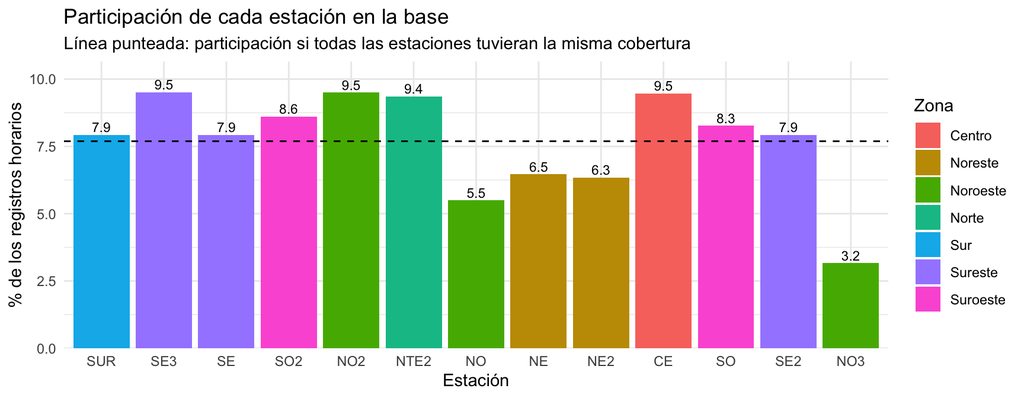

```r
tab_est <- tab_cat |>
  filter(variable == "Estación") |>
  left_join(distinct(cat_base, estacion, zona) |> mutate(categoria = as.character(estacion)) |>
              select(categoria, zona), by = "categoria") |>
  mutate(categoria = factor(categoria, levels = levels(cat_base$estacion)))

g_cat_est <- ggplot(tab_est, aes(categoria, pct, fill = zona)) +
  geom_col() +
  geom_text(aes(label = sprintf("%.1f", pct)), vjust = -0.3, size = 3) +
  geom_hline(yintercept = 100 / n_distinct(cat_base$estacion), linetype = 2) +
  scale_y_continuous(expand = expansion(mult = c(0, .12))) +
  labs(x = "Estación", y = "% de los registros horarios", fill = "Zona",
       title = "Participación de cada estación en la base",
       subtitle = "Línea punteada: participación si todas las estaciones tuvieran la misma cobertura")

col_aire <- c("Buena" = "#00E400", "Aceptable" = "#FFFF00", "Mala" = "#FF7E00",
              "Muy mala" = "#FF0000", "Extremadamente mala" = "#8F3F97")

tab_aire <- tab_cat |>
  filter(variable == "Calidad del aire (categoría)") |>
  mutate(categoria = factor(categoria, levels = names(col_aire)))

g_cat_aire <- ggplot(tab_aire, aes(categoria, pct, fill = categoria)) +
  geom_col(color = "grey30") +
  geom_text(aes(label = sprintf("%.2f %%", pct)), vjust = -0.3, size = 3.2) +
  scale_fill_manual(values = col_aire, guide = "none") +
  scale_y_continuous(expand = expansion(mult = c(0, .12))) +
  labs(x = NULL, y = "% de los registros horarios",
       title = "Categoría de calidad del aire (PM2.5, promedio móvil de 24 h)")

g_cat_est
```

**Código**

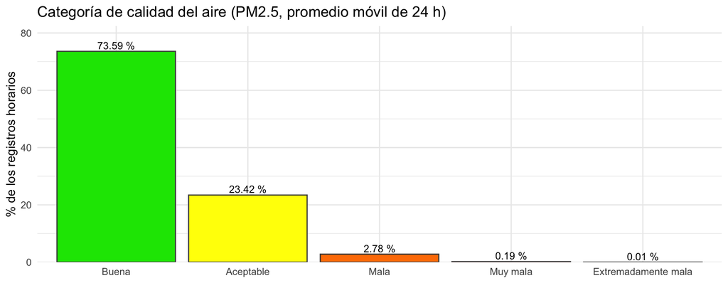

```r
g_cat_aire
```

**Código**

```r
ggsave("salidas/cat_estaciones.png",   g_cat_est,  width = 6.5, height = 3.2, dpi = 300)
ggsave("salidas/cat_calidad_aire.png", g_cat_aire, width = 6.5, height = 3.0, dpi = 300)
```

# 5 Exploración descriptiva orientada al objetivo

## 5.1 Cobertura de datos: ¿son comparables las estaciones?

**Pregunta.** Para decir que una zona es mejor que otra, las estaciones deben tener datos comparables. Si una estación solo tiene dos años o muchos huecos, su promedio no se puede comparar de forma directa. Se calcula, por estación y año, el porcentaje de días del año con PM2.5 válido (regla de `min_horas_dia`) y el porcentaje de la malla horaria presente.

**Código**

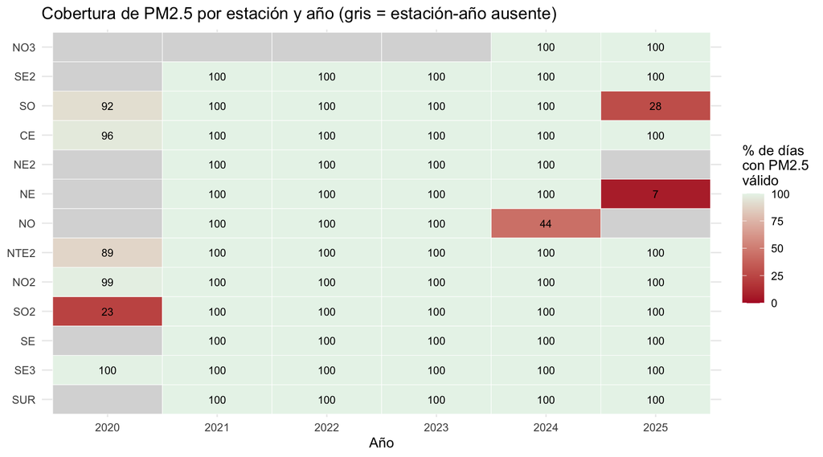

```r
dias_anio <- tibble(anio = sort(unique(datos_e2$anio))) |>
  mutate(dias = if_else(leap_year(anio), 366, 365))

cobertura <- datos_dia |>
  group_by(estacion, anio) |>
  summarise(dias_PM25 = sum(!is.na(PM25)), dias_PM10 = sum(!is.na(PM10)), .groups = "drop") |>
  left_join(datos_e2 |> count(estacion, anio, name = "horas"), by = c("estacion", "anio")) |>
  left_join(dias_anio, by = "anio") |>
  mutate(pct_dias_PM25 = dias_PM25 / dias * 100,
         pct_dias_PM10 = dias_PM10 / dias * 100,
         pct_horas     = horas / (dias * 24) * 100) |>
  complete(estacion, anio)

ggplot(cobertura, aes(factor(anio), estacion, fill = pct_dias_PM25)) +
  geom_tile(color = "white") +
  geom_text(aes(label = round(pct_dias_PM25)), size = 3) +
  scale_fill_gradient(low = "#b2182b", high = "#e8f4ea", limits = c(0, 100), na.value = "grey85") +
  labs(x = "Año", y = NULL, fill = "% de días\ncon PM2.5\nválido",
       title = "Cobertura de PM2.5 por estación y año (gris = estación-año ausente)")
```

**Código**

```r
cobertura |> group_by(estacion) |>
    summarise(`años con datos` = sum(!is.na(dias_PM25)),
            `años completos (≥ 90 % de días)` = sum(pct_dias_PM25 >= 90, na.rm = TRUE),
            `% días PM2.5 válidos (años presentes)` = mean(pct_dias_PM25, na.rm = TRUE),
            `% días PM10 válidos (años presentes)`  = mean(pct_dias_PM10, na.rm = TRUE),
            `% malla horaria presente` = mean(pct_horas, na.rm = TRUE)) |>
  kable(digits = 1, caption = "Cobertura promedio por estación")
```

Cobertura promedio por estación

| estacion | años con datos | años completos (≥ 90 % de días) | % días PM2.5 válidos (años presentes) | % días PM10 válidos (años presentes) | % malla horaria presente |
| --- | --- | --- | --- | --- | --- |
| SUR | 5 | 5 | 100.0 | 100.0 | 100.0 |
| SE3 | 6 | 6 | 100.0 | 100.0 | 100.0 |
| SE | 5 | 5 | 100.0 | 100.0 | 100.0 |
| SO2 | 6 | 5 | 87.2 | 87.2 | 90.5 |
| NO2 | 6 | 6 | 99.8 | 99.8 | 99.8 |
| NTE2 | 6 | 5 | 98.1 | 98.1 | 98.3 |
| NO | 4 | 3 | 86.0 | 86.0 | 86.7 |
| NE | 5 | 4 | 81.3 | 81.3 | 81.5 |
| NE2 | 4 | 4 | 100.0 | 100.0 | 100.0 |
| CE | 6 | 6 | 99.4 | 99.4 | 99.4 |
| SO | 6 | 5 | 86.7 | 86.7 | 86.9 |
| SE2 | 5 | 5 | 100.0 | 100.0 | 100.0 |
| NO3 | 2 | 2 | 99.9 | 99.9 | 99.9 |

**Qué mirar.** Estaciones-año ausentes (gris) o con cobertura parcial (rojo). Solo 2021-2023 tienen cobertura completa en todas las estaciones con datos en esos años; 2020 cubre la mitad de la red y 2024-2025 pierden estaciones o tienen años parciales. Por eso las comparaciones entre estaciones, zonas y meses de las secciones 5.4 a 5.12 se hacen sobre el **periodo común 2021-2023**, mientras que distribución, relación PM2.5-PM10 y estabilidad anual usan todos los años.

## 5.2 Distribución de PM2.5 y PM10

**Pregunta.** ¿Cómo es la forma, la variabilidad y la cola de las concentraciones? Esto determina si conviene trabajar con medias o con medianas, y si hay que transformar (log) antes de métodos como PCA o conglomerados.

**Código**

```r
asim <- function(x) { x <- x[is.finite(x)]; mean(((x - mean(x)) / sd(x))^3) }
resumen_num <- function(x) {
  q <- unname(quantile(x, c(.25, .5, .75, .95, .99), na.rm = TRUE))
  tibble(n = sum(!is.na(x)), media = mean(x, na.rm = TRUE), desv = sd(x, na.rm = TRUE),
         mín = min(x, na.rm = TRUE), q1 = q[1], mediana = q[2], q3 = q[3],
         p95 = q[4], p99 = q[5], máx = max(x, na.rm = TRUE),
         asimetría = asim(x), cv = sd(x, na.rm = TRUE) / mean(x, na.rm = TRUE))
}

tab_uni <- bind_rows(
  mutate(resumen_num(datos_e2$PM25),  base = "Horaria", variable = "PM2.5"),
  mutate(resumen_num(datos_e2$PM10),  base = "Horaria", variable = "PM10"),
  mutate(resumen_num(datos_dia$PM25), base = "Diaria",  variable = "PM2.5"),
  mutate(resumen_num(datos_dia$PM10), base = "Diaria",  variable = "PM10")
) |> select(base, variable, everything())
kable(tab_uni, digits = 2, format.args = list(big.mark = ","), caption = "Medidas de resumen de PM2.5 y PM10 (µg/m³)")
```

Medidas de resumen de PM2.5 y PM10 (µg/m³)

| base | variable | n | media | desv | mín | q1 | mediana | q3 | p95 | p99 | máx | asimetría | cv |
| --- | --- | --- | --- | --- | --- | --- | --- | --- | --- | --- | --- | --- | --- |
| Horaria | PM2.5 | 552,503 | 20.60 | 15.31 | 0.00 | 10.82 | 17.00 | 26.71 | 47.00 | 70.84 | 782.00 | 5.09 | 0.74 |
| Horaria | PM10 | 552,503 | 60.14 | 40.58 | 1.61 | 35.00 | 51.00 | 73.10 | 129.00 | 208.00 | 811.00 | 3.39 | 0.67 |
| Diaria | PM2.5 | 22,930 | 20.60 | 10.87 | 2.00 | 13.00 | 18.31 | 25.67 | 40.31 | 56.67 | 163.16 | 1.90 | 0.53 |
| Diaria | PM10 | 22,930 | 60.17 | 28.28 | 4.90 | 40.96 | 54.71 | 73.33 | 113.21 | 155.95 | 308.15 | 1.57 | 0.47 |

**Código**

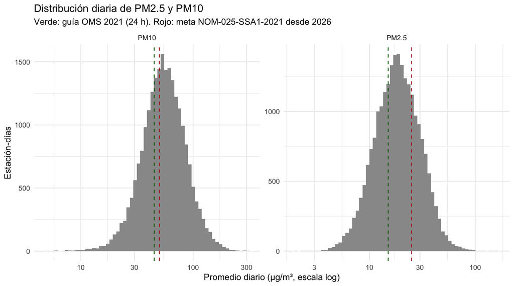

```r
lim_ref <- tibble(contaminante = c("PM2.5", "PM10"), oms = c(15, 45), nom_meta = c(25, 50))

datos_dia |>
  select(PM25, PM10) |>
  pivot_longer(everything(), names_to = "contaminante", values_to = "valor") |>
  mutate(contaminante = recode(contaminante, PM25 = "PM2.5")) |>
  filter(!is.na(valor), valor > 0) |>
  ggplot(aes(valor)) +
  geom_histogram(bins = 60, fill = "grey60") +
  geom_vline(data = lim_ref, aes(xintercept = oms), color = "darkgreen", linetype = 2) +
  geom_vline(data = lim_ref, aes(xintercept = nom_meta), color = "firebrick", linetype = 2) +
  scale_x_log10() +
  facet_wrap(~contaminante, scales = "free") +
  labs(x = "Promedio diario (µg/m³, escala log)", y = "Estación-días",
       title = "Distribución diaria de PM2.5 y PM10",
       subtitle = "Verde: guía OMS 2021 (24 h). Rojo: meta NOM-025-SSA1-2021 desde 2026")
```

**Código**

```r
tukey <- function(x, k) { q <- quantile(x, c(.25, .75), na.rm = TRUE); x > q[2] + k * (q[2] - q[1]) }

map_dfr(c("PM25", "PM10"), \(v) {
  x <- datos_dia[[v]]
  tibble(variable = v, `días válidos` = sum(!is.na(x)),
         `> Q3 + 1.5·IQR` = sum(tukey(x, 1.5), na.rm = TRUE),
         `> Q3 + 3·IQR`   = sum(tukey(x, 3),   na.rm = TRUE),
         `% extremos (3·IQR)` = mean(tukey(x, 3), na.rm = TRUE) * 100)
}) |> kable(digits = 2, format.args = list(big.mark = ","), caption = "Valores atípicos en promedios diarios (regla de Tukey)")
```

Valores atípicos en promedios diarios (regla de Tukey)

| variable | días válidos | > Q3 + 1.5·IQR | > Q3 + 3·IQR | % extremos (3·IQR) |
| --- | --- | --- | --- | --- |
| PM25 | 22,930 | 701 | 134 | 0.58 |
| PM10 | 22,930 | 817 | 135 | 0.59 |

**Código**

```r
datos_dia |> arrange(desc(PM25)) |>
  select(estacion, dia, PM25, PM25_max, PM10) |> slice_head(n = 10) |>
  kable(digits = 1, caption = "Diez días con mayor PM2.5 diario")
```

Diez días con mayor PM2.5 diario

| estacion | dia | PM25 | PM25_max | PM10 |
| --- | --- | --- | --- | --- |
| NE | 2024-01-01 | 163.2 |  | 196.6 |
| SE2 | 2023-12-31 | 150.0 |  | 159.7 |
| NE | 2023-12-31 | 139.4 |  | 148.7 |
| SE3 | 2024-01-01 | 139.2 |  | 202.0 |
| SE2 | 2022-01-01 | 117.6 |  | 184.0 |
| SE2 | 2021-12-25 | 116.3 |  | 152.1 |
| SE2 | 2022-01-14 | 113.7 |  | 147.4 |
| NE | 2023-01-01 | 112.1 |  | 169.7 |
| SE2 | 2023-12-17 | 103.8 |  | 171.9 |
| SO | 2022-01-08 | 101.5 |  | 135.9 |

**Qué mirar.** Asimetría positiva fuerte y diferencia media-mediana (cola derecha); si los días más altos coinciden con fechas de pirotecnia o con un mes frío; si las medianas ya superan las guías de la OMS.

## 5.3 Relación entre PM2.5 y PM10

**Pregunta.** Si PM2.5 y PM10 están muy correlacionadas, un solo índice (PCA) podría resumir ambas; si no, aportan información distinta. La razón PM2.5/PM10 indica qué fracción de las partículas es fina (combustión) frente a gruesa (polvo, pedreras).

**Código**

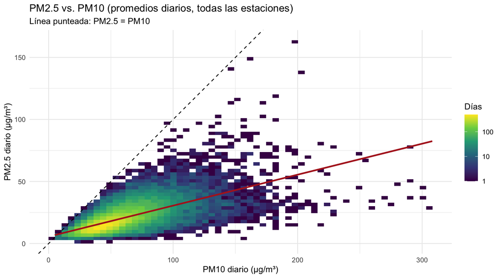

```r
datos_dia |> filter(!is.na(PM25), !is.na(PM10)) |>
  ggplot(aes(PM10, PM25)) +
  geom_bin2d(bins = 60) +
  scale_fill_viridis_c(trans = "log10") +
  geom_abline(slope = 1, intercept = 0, linetype = 2) +
  geom_smooth(method = "lm", se = FALSE, color = "firebrick") +
  labs(x = "PM10 diario (µg/m³)", y = "PM2.5 diario (µg/m³)", fill = "Días",
       title = "PM2.5 vs. PM10 (promedios diarios, todas las estaciones)",
       subtitle = "Línea punteada: PM2.5 = PM10")
```

**Código**

```r
rel_est <- datos_dia |> filter(!is.na(PM25), !is.na(PM10)) |>
  group_by(estacion) |>
  summarise(días = n(),
            `r Pearson`  = cor(PM25, PM10),
            `r Spearman` = cor(PM25, PM10, method = "spearman"),
            `razón PM2.5/PM10 (mediana)` = median(PM25 / PM10),
            .groups = "drop")
kable(rel_est, digits = 2, caption = "Relación PM2.5-PM10 por estación (diaria)")
```

Relación PM2.5-PM10 por estación (diaria)

| estacion | días | r Pearson | r Spearman | razón PM2.5/PM10 (mediana) |
| --- | --- | --- | --- | --- |
| SUR | 1826 | 0.64 | 0.69 | 0.35 |
| SE3 | 2191 | 0.70 | 0.74 | 0.27 |
| SE | 1826 | 0.69 | 0.75 | 0.35 |
| SO2 | 1911 | 0.63 | 0.69 | 0.30 |
| NO2 | 2187 | 0.41 | 0.41 | 0.33 |
| NTE2 | 2151 | 0.63 | 0.67 | 0.31 |
| NO | 1256 | 0.69 | 0.80 | 0.43 |
| NE | 1485 | 0.71 | 0.75 | 0.34 |
| NE2 | 1461 | 0.71 | 0.77 | 0.31 |
| CE | 2179 | 0.68 | 0.71 | 0.38 |
| SO | 1901 | 0.71 | 0.79 | 0.39 |
| SE2 | 1826 | 0.77 | 0.79 | 0.39 |
| NO3 | 730 | 0.54 | 0.53 | 0.34 |

## 5.4 Comparación entre estaciones y zonas

**Pregunta.** ¿Qué estaciones y zonas tienen más y menos PM2.5 y PM10? ¿Qué tan grande es la diferencia respecto a la variabilidad dentro de cada estación? Los gráficos se acotan al percentil 99.5 para que las cajas se vean; la tabla usa todos los datos.

**Código**

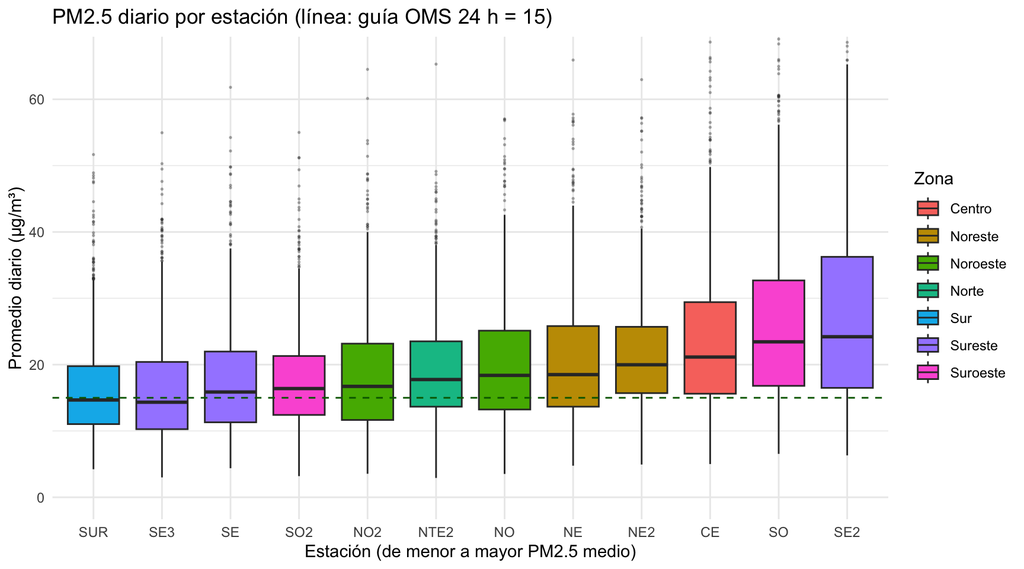

```r
lim_y <- function(v) quantile(datos_dia_c[[v]], .995, na.rm = TRUE)

p_est <- function(v, titulo, oms) {
  ggplot(datos_dia_c, aes(estacion, .data[[v]], fill = zona)) +
    geom_boxplot(outlier.size = .3, outlier.alpha = .3) +
    geom_hline(yintercept = oms, linetype = 2, color = "darkgreen") +
    coord_cartesian(ylim = c(0, lim_y(v))) +
    labs(x = "Estación (de menor a mayor PM2.5 medio)", y = "Promedio diario (µg/m³)", fill = "Zona", title = titulo)
}
p_est("PM25", "PM2.5 diario por estación (línea: guía OMS 24 h = 15)", 15)
```

**Código**

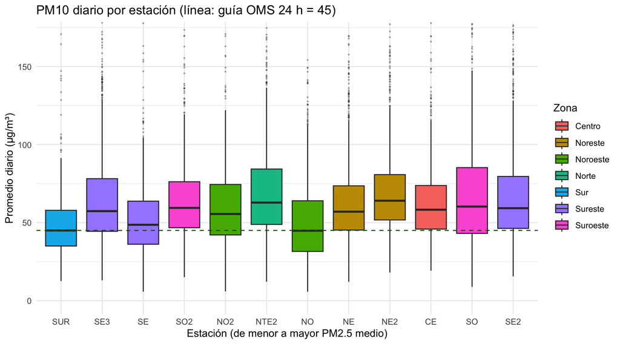

```r
p_est("PM10", "PM10 diario por estación (línea: guía OMS 24 h = 45)", 45)
```

**Código**

```r
res_est <- datos_dia_c |>
  group_by(estacion, zona, msnm) |>
  summarise(`días PM2.5` = sum(!is.na(PM25)),
            `PM2.5 media` = mean(PM25, na.rm = TRUE), `PM2.5 mediana` = median(PM25, na.rm = TRUE),
            `PM2.5 IQR` = IQR(PM25, na.rm = TRUE), `PM2.5 p95` = quantile(PM25, .95, na.rm = TRUE),
            `PM10 media` = mean(PM10, na.rm = TRUE), `PM10 mediana` = median(PM10, na.rm = TRUE),
            `PM10 IQR` = IQR(PM10, na.rm = TRUE), `PM10 p95` = quantile(PM10, .95, na.rm = TRUE),
            .groups = "drop") |>
  arrange(`PM2.5 media`)
kable(res_est, digits = 1, caption = "Resumen de PM2.5 y PM10 diarios por estación, 2021-2023 (µg/m³)")
```

Resumen de PM2.5 y PM10 diarios por estación, 2021-2023 (µg/m³)

| estacion | zona | msnm | días PM2.5 | PM2.5 media | PM2.5 mediana | PM2.5 IQR | PM2.5 p95 | PM10 media | PM10 mediana | PM10 IQR | PM10 p95 |
| --- | --- | --- | --- | --- | --- | --- | --- | --- | --- | --- | --- |
| SUR | Sur | 555 | 1095 | 16.3 | 14.7 | 8.7 | 30.4 | 48.0 | 45.0 | 22.9 | 80.1 |
| SE3 | Sureste | 334 | 1095 | 16.4 | 14.3 | 10.1 | 32.3 | 65.0 | 57.4 | 33.7 | 128.9 |
| SE | Sureste | 500 | 1095 | 17.5 | 15.9 | 10.7 | 32.5 | 51.8 | 48.6 | 27.6 | 92.0 |
| SO2 | Suroeste | 636 | 1095 | 17.6 | 16.4 | 8.9 | 31.2 | 64.3 | 59.5 | 29.5 | 108.1 |
| NO2 | Noroeste | 702 | 1095 | 18.5 | 16.7 | 11.5 | 36.6 | 59.4 | 55.5 | 32.3 | 100.9 |
| NTE2 | Norte | 520 | 1095 | 19.3 | 17.8 | 9.8 | 33.9 | 69.2 | 62.8 | 35.5 | 122.4 |
| NO | Noroeste | 568 | 1095 | 20.2 | 18.4 | 11.9 | 36.6 | 50.4 | 44.8 | 32.5 | 97.6 |
| NE | Noreste | 474 | 1095 | 20.9 | 18.5 | 12.2 | 39.0 | 62.6 | 57.0 | 28.3 | 117.3 |
| NE2 | Noreste | 432 | 1095 | 21.5 | 20.0 | 10.0 | 37.0 | 69.1 | 64.0 | 29.1 | 121.7 |
| CE | Centro | 562 | 1095 | 23.5 | 21.1 | 13.8 | 43.0 | 62.5 | 58.3 | 27.9 | 104.7 |
| SO | Suroeste | 674 | 1095 | 26.3 | 23.4 | 15.9 | 52.3 | 67.7 | 60.3 | 42.2 | 128.0 |
| SE2 | Sureste | 387 | 1095 | 28.1 | 24.2 | 19.8 | 57.0 | 67.6 | 59.2 | 33.3 | 132.6 |

**Código**

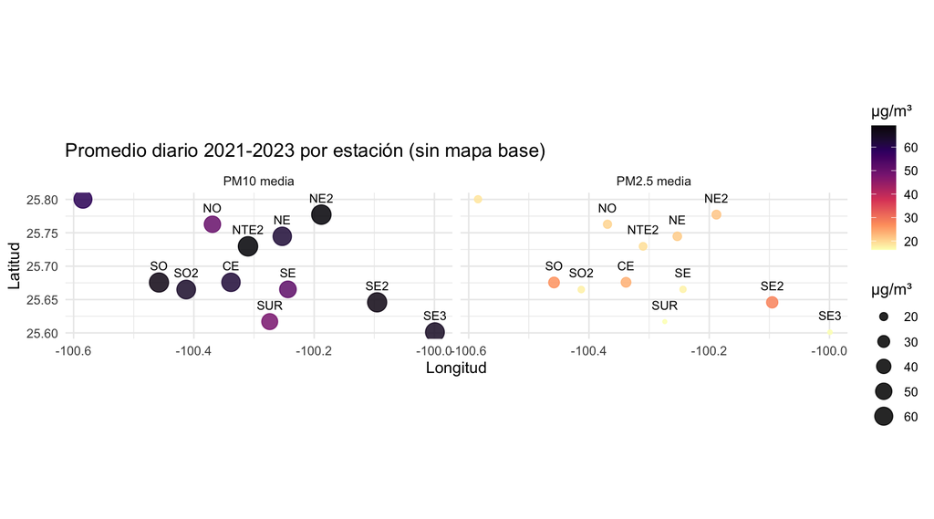

```r
res_est |> left_join(catalogo, by = "estacion") |>
  pivot_longer(c(`PM2.5 media`, `PM10 media`), names_to = "contaminante", values_to = "media") |>
  ggplot(aes(lon, lat, size = media, color = media)) +
  geom_point(alpha = .85) +
  geom_text(aes(label = estacion), color = "black", size = 3, vjust = -1.4) +
  scale_color_viridis_c(option = "magma", direction = -1) +
  facet_wrap(~contaminante) +
  coord_quickmap() +
  labs(x = "Longitud", y = "Latitud", size = "µg/m³", color = "µg/m³",
       title = "Promedio diario 2021-2023 por estación (sin mapa base)")
```

**Código**

```r
res_zona <- res_est |>
  group_by(zona) |>
  summarise(estaciones = paste(estacion, collapse = ", "), `n estaciones` = n(),
            `PM2.5 media de estaciones` = mean(`PM2.5 media`),
            `PM2.5 mín-máx entre estaciones` = sprintf("%.1f - %.1f", min(`PM2.5 media`), max(`PM2.5 media`)),
            `PM10 media de estaciones` = mean(`PM10 media`),
            `PM10 mín-máx entre estaciones` = sprintf("%.1f - %.1f", min(`PM10 media`), max(`PM10 media`)),
            .groups = "drop") |>
  arrange(`PM2.5 media de estaciones`)
kable(res_zona, digits = 1, caption = "Resumen por zona (promedio de los promedios de sus estaciones)")
```

Resumen por zona (promedio de los promedios de sus estaciones)

| zona | estaciones | n estaciones | PM2.5 media de estaciones | PM2.5 mín-máx entre estaciones | PM10 media de estaciones | PM10 mín-máx entre estaciones |
| --- | --- | --- | --- | --- | --- | --- |
| Sur | SUR | 1 | 16.3 | 16.3 - 16.3 | 48.0 | 48.0 - 48.0 |
| Norte | NTE2 | 1 | 19.3 | 19.3 - 19.3 | 69.2 | 69.2 - 69.2 |
| Noroeste | NO2, NO | 2 | 19.4 | 18.5 - 20.2 | 54.9 | 50.4 - 59.4 |
| Sureste | SE3, SE, SE2 | 3 | 20.6 | 16.4 - 28.1 | 61.5 | 51.8 - 67.6 |
| Noreste | NE, NE2 | 2 | 21.2 | 20.9 - 21.5 | 65.9 | 62.6 - 69.1 |
| Suroeste | SO2, SO | 2 | 22.0 | 17.6 - 26.3 | 66.0 | 64.3 - 67.7 |
| Centro | CE | 1 | 23.5 | 23.5 - 23.5 | 62.5 | 62.5 - 62.5 |

**Qué mirar.** Cuántas estaciones tiene cada zona (si hay zonas con una sola estación, “zona” y “estación” son lo mismo), qué tan separadas están las cajas entre estaciones frente al ancho de cada caja y si la diferencia entre estaciones de una misma zona es comparable a la diferencia entre zonas.

## 5.5 ¿Qué pesa más: estación, zona, mes o año?

**Pregunta.** Para decidir si el objetivo debe centrarse en el “dónde”, en el “cuándo” o en ambos, se mide cuánta variabilidad de log(PM) diario explica cada factor por separado (R² de un modelo lineal de un solo factor) y combinados. Es una descomposición descriptiva, no una prueba de hipótesis.

**Código**

```r
r2 <- function(formula, data) summary(lm(formula, data = data))$r.squared

r2_tab <- function(y, nombre) {
  d <- datos_dia_c |> filter(!is.na(.data[[y]]), .data[[y]] > 0) |>
    mutate(ly = log(.data[[y]]), mes_f = factor(mes), anio_f = factor(anio))
  tibble(contaminante = nombre,
         factor = c("estación", "zona", "mes", "año", "estación + mes", "estación + mes + año"),
         R2 = c(r2(ly ~ estacion, d), r2(ly ~ zona, d), r2(ly ~ mes_f, d),
                r2(ly ~ anio_f, d), r2(ly ~ estacion + mes_f, d), r2(ly ~ estacion + mes_f + anio_f, d)))
}
bind_rows(r2_tab("PM25", "PM2.5"), r2_tab("PM10", "PM10")) |>
  pivot_wider(names_from = contaminante, values_from = R2) |>
  kable(digits = 3, caption = "Proporción de la variabilidad de log(PM) diario explicada por cada factor (R²)")
```

Proporción de la variabilidad de log(PM) diario explicada por cada factor (R²)

| factor | PM2.5 | PM10 |
| --- | --- | --- |
| estación | 0.115 | 0.087 |
| zona | 0.033 | 0.057 |
| mes | 0.115 | 0.135 |
| año | 0.002 | 0.002 |
| estación + mes | 0.230 | 0.222 |
| estación + mes + año | 0.232 | 0.224 |

## 5.6 Estacionalidad: ¿qué meses son mejores y peores?

**Pregunta.** ¿Hay meses consistentemente más limpios o más contaminados? ¿El patrón es el mismo en todas las estaciones o varía por zona? Un promedio estación-mes solo se acepta con al menos `min_dias_mes` días válidos.

**Código**

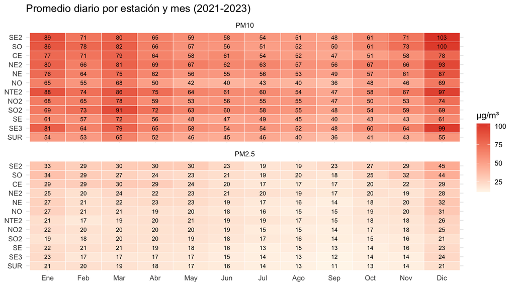

```r
sm <- datos_dia_c |>
  group_by(estacion, zona, mes_lab) |>
  summarise(dias25 = sum(!is.na(PM25)), dias10 = sum(!is.na(PM10)),
            PM25 = if_else(dias25 >= min_dias_mes, mean(PM25, na.rm = TRUE), NA_real_),
            PM10 = if_else(dias10 >= min_dias_mes, mean(PM10, na.rm = TRUE), NA_real_),
            .groups = "drop")

sm |> pivot_longer(c(PM25, PM10), names_to = "contaminante", values_to = "media") |>
  mutate(contaminante = recode(contaminante, PM25 = "PM2.5")) |>
  ggplot(aes(mes_lab, estacion, fill = media)) +
  geom_tile(color = "white") +
  geom_text(aes(label = round(media)), size = 2.6) +
  scale_fill_gradient(low = "#fff7ec", high = "#e34a33", na.value = "grey85") +
  facet_wrap(~contaminante, ncol = 1) +
  labs(x = NULL, y = NULL, fill = "µg/m³",
       title = "Promedio diario por estación y mes (2021-2023)")
```

**Código**

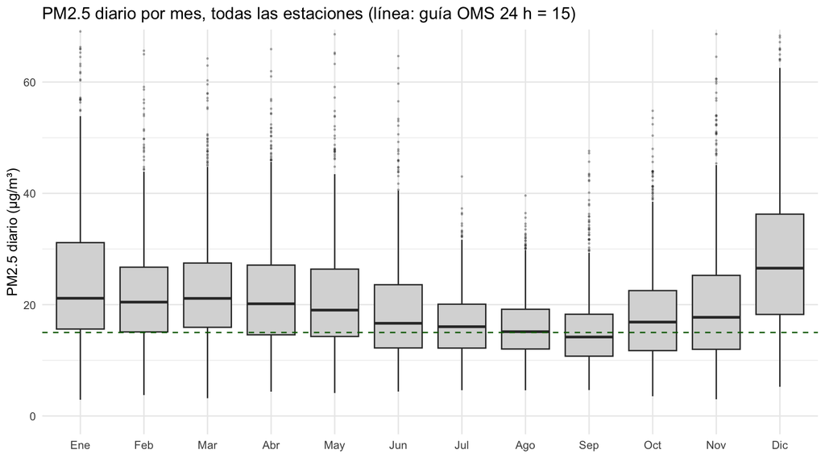

```r
datos_dia_c |> filter(!is.na(PM25)) |>
  ggplot(aes(mes_lab, PM25)) +
  geom_boxplot(outlier.size = .3, outlier.alpha = .3, fill = "grey85") +
  geom_hline(yintercept = 15, linetype = 2, color = "darkgreen") +
  coord_cartesian(ylim = c(0, lim_y("PM25"))) +
  labs(x = NULL, y = "PM2.5 diario (µg/m³)",
       title = "PM2.5 diario por mes, todas las estaciones (línea: guía OMS 24 h = 15)")
```

**Código**

```r
pico <- sm |> filter(!is.na(PM25)) |> group_by(estacion) |>
  summarise(`mes más alto` = as.character(mes_lab[which.max(PM25)]), `PM2.5 máx. mensual` = max(PM25),
            `mes más bajo` = as.character(mes_lab[which.min(PM25)]), `PM2.5 mín. mensual` = min(PM25),
            `razón máx/mín` = max(PM25) / min(PM25), .groups = "drop")
kable(pico, digits = 1, caption = "Mes más alto y más bajo de PM2.5 por estación")
```

Mes más alto y más bajo de PM2.5 por estación

| estacion | mes más alto | PM2.5 máx. mensual | mes más bajo | PM2.5 mín. mensual | razón máx/mín |
| --- | --- | --- | --- | --- | --- |
| SUR | Dic | 20.7 | Sep | 11.1 | 1.9 |
| SE3 | Dic | 24.1 | Sep | 11.5 | 2.1 |
| SE | Dic | 23.2 | Sep | 12.6 | 1.8 |
| SO2 | Dic | 20.8 | Sep | 14.2 | 1.5 |
| NO2 | Dic | 25.0 | Sep | 13.8 | 1.8 |
| NTE2 | Dic | 26.4 | Sep | 15.1 | 1.7 |
| NO | Dic | 31.3 | Ago | 14.5 | 2.2 |
| NE | Dic | 32.0 | Sep | 14.1 | 2.3 |
| NE2 | Dic | 28.0 | Sep | 16.9 | 1.7 |
| CE | Mar | 30.4 | Ago | 16.9 | 1.8 |
| SO | Dic | 43.7 | Sep | 18.4 | 2.4 |
| SE2 | Dic | 45.1 | Jul | 18.8 | 2.4 |

**Perfil relativo: nivel vs. forma.** Si cada estación se divide entre su propio promedio, queda solo la *forma* del ciclo anual. Si la forma es parecida en todas las estaciones y lo que cambia es el *nivel*, entonces “en qué mes” es una pregunta común a toda la ciudad y “dónde” es una pregunta de nivel.

**Código**

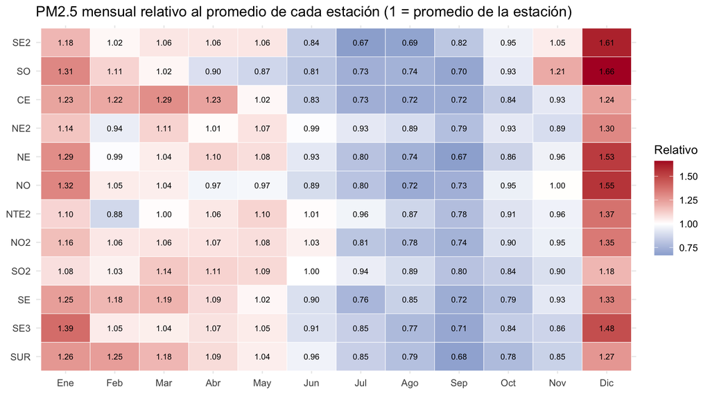

```r
sm |> filter(!is.na(PM25)) |>
  group_by(estacion) |> mutate(relativo = PM25 / mean(PM25)) |> ungroup() |>
  ggplot(aes(mes_lab, estacion, fill = relativo)) +
  geom_tile(color = "white") +
  geom_text(aes(label = sprintf("%.2f", relativo)), size = 2.6) +
  scale_fill_gradient2(midpoint = 1, low = "#2166ac", mid = "white", high = "#b2182b") +
  labs(x = NULL, y = NULL, fill = "Relativo",
       title = "PM2.5 mensual relativo al promedio de cada estación (1 = promedio de la estación)")
```

**Código**

```r
perfil_w <- sm |> select(estacion, mes_lab, PM25) |> pivot_wider(names_from = mes_lab, values_from = PM25)
cor_perfil <- cor(t(as.matrix(perfil_w[, -1])), use = "pairwise.complete.obs")
rownames(cor_perfil) <- colnames(cor_perfil) <- as.character(perfil_w$estacion)
cat("Correlación entre perfiles mensuales de PM2.5 de distintas estaciones (pares): mínimo =",
    round(min(cor_perfil[upper.tri(cor_perfil)], na.rm = TRUE), 2), "| mediana =",
    round(median(cor_perfil[upper.tri(cor_perfil)], na.rm = TRUE), 2), "\n")
```

```
Correlación entre perfiles mensuales de PM2.5 de distintas estaciones (pares): mínimo = 0.57 | mediana = 0.86
```

**Código**

```r
# ¿Sigue siendo diciembre el peor mes si se excluyen los días de pirotecnia (24-dic a 1-ene)?
dias_pirot <- function(d) (month(d) == 12 & day(d) >= 24) | (month(d) == 1 & day(d) == 1)
datos_dia_c |>
  mutate(pirotecnia = dias_pirot(dia)) |>
  group_by(mes_lab) |>
  summarise(`PM2.5 con todos los días`  = mean(PM25, na.rm = TRUE),
            `PM2.5 sin 24-dic a 1-ene`  = mean(PM25[!pirotecnia], na.rm = TRUE),
            `días excluidos`            = sum(pirotecnia), .groups = "drop") |>
  kable(digits = 1, caption = "Sensibilidad del perfil mensual a los días de pirotecnia (2021-2023)")
```

Sensibilidad del perfil mensual a los días de pirotecnia (2021-2023)

| mes_lab | PM2.5 con todos los días | PM2.5 sin 24-dic a 1-ene | días excluidos |
| --- | --- | --- | --- |
| Ene | 25.1 | 24.4 | 36 |
| Feb | 21.8 | 21.8 | 0 |
| Mar | 22.5 | 22.5 | 0 |
| Abr | 21.7 | 21.7 | 0 |
| May | 21.2 | 21.2 | 0 |
| Jun | 18.8 | 18.8 | 0 |
| Jul | 16.6 | 16.6 | 0 |
| Ago | 16.0 | 16.0 | 0 |
| Sep | 15.2 | 15.2 | 0 |
| Oct | 18.1 | 18.1 | 0 |
| Nov | 19.9 | 19.9 | 0 |
| Dic | 29.1 | 28.5 | 288 |

## 5.7 Estabilidad entre años y cumplimiento anual

**Pregunta.** ¿El nivel de cada estación es estable entre años, o domina un año atípico (por ejemplo 2020)? ¿Qué estaciones superan el límite anual? Se acepta un promedio anual con al menos `min_dias_anio` días válidos.

**Código**

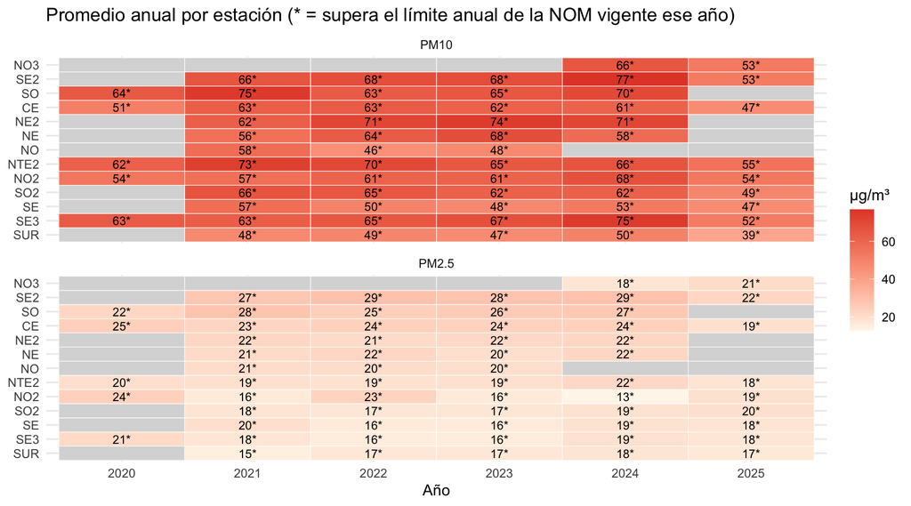

```r
anual <- datos_dia |>
  group_by(estacion, anio) |>
  summarise(d25 = sum(!is.na(PM25)), d10 = sum(!is.na(PM10)),
            PM25 = if_else(d25 >= min_dias_anio, mean(PM25, na.rm = TRUE), NA_real_),
            PM10 = if_else(d10 >= min_dias_anio, mean(PM10, na.rm = TRUE), NA_real_),
            .groups = "drop") |>
  left_join(lim_norma |> select(anio, PM25_anual, PM10_anual), by = "anio") |>
  complete(estacion, anio)

anual |>
  pivot_longer(c(PM25, PM10), names_to = "contaminante", values_to = "media") |>
  mutate(limite = if_else(contaminante == "PM25", PM25_anual, PM10_anual),
         etiqueta = if_else(is.na(media), "", paste0(round(media), if_else(media > limite, "*", ""))),
         contaminante = recode(contaminante, PM25 = "PM2.5")) |>
  ggplot(aes(factor(anio), estacion, fill = media)) +
  geom_tile(color = "white") +
  geom_text(aes(label = etiqueta), size = 3) +
  scale_fill_gradient(low = "#fff7ec", high = "#e34a33", na.value = "grey85") +
  facet_wrap(~contaminante, ncol = 1) +
  labs(x = "Año", y = NULL, fill = "µg/m³",
       title = "Promedio anual por estación (* = supera el límite anual de la NOM vigente ese año)")
```

**Código**

```r
anual |> group_by(anio) |>
  summarise(`PM2.5 media entre estaciones` = mean(PM25, na.rm = TRUE),
            `PM10 media entre estaciones`  = mean(PM10, na.rm = TRUE),
            `estaciones con PM2.5 anual válido` = sum(!is.na(PM25)),
            `PM2.5 > límite NOM anual` = sum(PM25 > PM25_anual, na.rm = TRUE),
            `PM2.5 > guía OMS anual (5)` = sum(PM25 > lim_oms[["PM25_anual"]], na.rm = TRUE)) |>
  kable(digits = 1, caption = "Resumen anual entre estaciones")
```

Resumen anual entre estaciones

| anio | PM2.5 media entre estaciones | PM10 media entre estaciones | estaciones con PM2.5 anual válido | PM2.5 > límite NOM anual | PM2.5 > guía OMS anual (5) |
| --- | --- | --- | --- | --- | --- |
| 2020 | 22.4 | 58.9 | 5 | 5 | 5 |
| 2021 | 20.7 | 61.9 | 12 | 12 | 12 |
| 2022 | 20.8 | 61.3 | 12 | 12 | 12 |
| 2023 | 20.0 | 61.3 | 12 | 12 | 12 |
| 2024 | 20.9 | 64.6 | 12 | 12 | 12 |
| 2025 | 19.1 | 49.9 | 9 | 9 | 9 |

## 5.8 Excedencias de los límites de 24 horas

**Pregunta.** ¿Con qué frecuencia y en qué meses cada estación supera los límites diarios? Se compara contra la NOM vigente en cada año y contra la guía de la OMS. La NOM evalúa el percentil 99 anual de los promedios de 24 h (Secretaría de Salud, 2021), por eso se reporta también.

**Código**

```r
exc <- datos_dia_c |>
  left_join(lim_norma |> select(anio, PM25_24h, PM10_24h), by = "anio") |>
  mutate(e25_nom = PM25 > PM25_24h, e25_oms = PM25 > lim_oms[["PM25_24h"]],
         e10_nom = PM10 > PM10_24h, e10_oms = PM10 > lim_oms[["PM10_24h"]])

exc |> group_by(estacion) |>
  summarise(`días PM2.5` = sum(!is.na(PM25)),
            `PM2.5 > NOM (%)` = mean(e25_nom, na.rm = TRUE) * 100,
            `PM2.5 > OMS (%)` = mean(e25_oms, na.rm = TRUE) * 100,
            `PM2.5 p99` = quantile(PM25, .99, na.rm = TRUE),
            `días PM10` = sum(!is.na(PM10)),
            `PM10 > NOM (%)` = mean(e10_nom, na.rm = TRUE) * 100,
            `PM10 > OMS (%)` = mean(e10_oms, na.rm = TRUE) * 100,
            `PM10 p99` = quantile(PM10, .99, na.rm = TRUE)) |>
  kable(digits = 1, caption = "Frecuencia de excedencias de 24 h por estación (2021-2023)")
```

Frecuencia de excedencias de 24 h por estación (2021-2023)

| estacion | días PM2.5 | PM2.5 > NOM (%) | PM2.5 > OMS (%) | PM2.5 p99 | días PM10 | PM10 > NOM (%) | PM10 > OMS (%) | PM10 p99 |
| --- | --- | --- | --- | --- | --- | --- | --- | --- |
| SUR | 1095 | 0.9 | 48.2 | 41.5 | 1095 | 9.9 | 49.9 | 104.4 |
| SE3 | 1095 | 1.0 | 46.5 | 41.9 | 1095 | 31.0 | 73.7 | 162.2 |
| SE | 1095 | 1.3 | 54.0 | 44.3 | 1095 | 16.6 | 57.0 | 117.0 |
| SO2 | 1095 | 0.7 | 59.9 | 40.2 | 1095 | 31.3 | 79.5 | 155.9 |
| NO2 | 1095 | 2.0 | 59.2 | 46.3 | 1095 | 28.2 | 71.1 | 135.2 |
| NTE2 | 1095 | 1.6 | 67.2 | 44.7 | 1095 | 37.2 | 81.7 | 167.3 |
| NO | 1095 | 2.4 | 66.7 | 50.9 | 1095 | 17.7 | 49.8 | 139.3 |
| NE | 1095 | 3.6 | 68.2 | 56.1 | 1095 | 27.8 | 75.3 | 149.7 |
| NE2 | 1095 | 2.6 | 79.0 | 48.0 | 1095 | 36.3 | 84.9 | 157.4 |
| CE | 1095 | 5.9 | 77.1 | 61.1 | 1095 | 27.9 | 76.5 | 134.1 |
| SO | 1095 | 10.3 | 82.3 | 72.1 | 1095 | 36.0 | 71.7 | 170.7 |
| SE2 | 1095 | 15.8 | 80.4 | 80.6 | 1095 | 32.3 | 77.3 | 172.0 |

**Código**

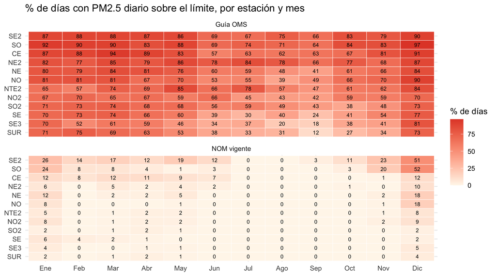

```r
exc |> group_by(estacion, mes_lab) |>
  summarise(d = sum(!is.na(PM25)),
            `NOM vigente` = mean(e25_nom, na.rm = TRUE) * 100,
            `Guía OMS` = mean(e25_oms, na.rm = TRUE) * 100, .groups = "drop") |>
  mutate(across(c(`NOM vigente`, `Guía OMS`), \(x) if_else(d >= min_dias_mes, x, NA_real_))) |>
  pivot_longer(c(`NOM vigente`, `Guía OMS`), names_to = "criterio", values_to = "pct") |>
  ggplot(aes(mes_lab, estacion, fill = pct)) +
  geom_tile(color = "white") +
  geom_text(aes(label = round(pct)), size = 2.5) +
  scale_fill_gradient(low = "#fff7ec", high = "#e34a33", na.value = "grey85") +
  facet_wrap(~criterio, ncol = 1) +
  labs(x = NULL, y = NULL, fill = "% de días",
       title = "% de días con PM2.5 diario sobre el límite, por estación y mes")
```

**Código**

```r
exc |> group_by(mes_lab) |>
  summarise(`PM2.5 > NOM (%)` = mean(e25_nom, na.rm = TRUE) * 100,
            `PM2.5 > OMS (%)` = mean(e25_oms, na.rm = TRUE) * 100,
            `PM10 > NOM (%)`  = mean(e10_nom, na.rm = TRUE) * 100,
            `PM10 > OMS (%)`  = mean(e10_oms, na.rm = TRUE) * 100) |>
  kable(digits = 1, caption = "% de días sobre el límite por mes (todas las estaciones)")
```

% de días sobre el límite por mes (todas las estaciones)

| mes_lab | PM2.5 > NOM (%) | PM2.5 > OMS (%) | PM10 > NOM (%) | PM10 > OMS (%) |
| --- | --- | --- | --- | --- |
| Ene | 9.6 | 76.8 | 47.2 | 81.5 |
| Feb | 2.9 | 75.3 | 34.9 | 77.9 |
| Mar | 4.2 | 78.2 | 50.2 | 87.2 |
| Abr | 3.6 | 73.1 | 31.4 | 75.7 |
| May | 3.9 | 71.7 | 19.3 | 71.7 |
| Jun | 2.0 | 56.9 | 19.3 | 62.2 |
| Jul | 0.0 | 57.1 | 14.0 | 66.9 |
| Ago | 0.0 | 51.3 | 9.7 | 59.9 |
| Sep | 0.3 | 44.6 | 3.5 | 49.9 |
| Oct | 1.3 | 58.4 | 17.0 | 61.6 |
| Nov | 4.3 | 62.1 | 26.1 | 67.2 |
| Dic | 15.9 | 83.2 | 59.2 | 86.4 |

## 5.9 Meteorología y contaminantes acompañantes

**Pregunta.** ¿Qué condiciones del clima acompañan a los meses y días altos de PM? La literatura vincula las concentraciones más altas con los meses fríos por inversiones térmicas y las más bajas con la época de lluvias (INECC, 2015; Molina et al., 2019). Primero el ciclo anual del clima, luego la correlación de rangos (Spearman, apropiada por la asimetría) por temporada.

**Código**

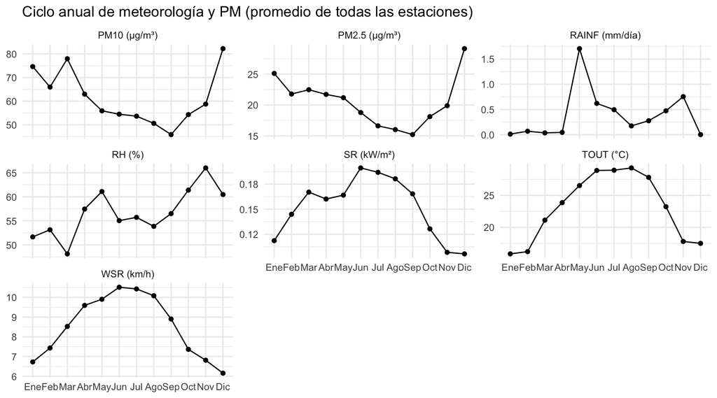

```r
datos_dia_c |>
  group_by(mes_lab) |>
  summarise(`TOUT (°C)` = mean(TOUT, na.rm = TRUE), `RH (%)` = mean(RH, na.rm = TRUE),
            `WSR (km/h)` = mean(WSR, na.rm = TRUE), `SR (kW/m²)` = mean(SR, na.rm = TRUE),
            `RAINF (mm/día)` = mean(RAINF, na.rm = TRUE),
            `PM2.5 (µg/m³)` = mean(PM25, na.rm = TRUE), `PM10 (µg/m³)` = mean(PM10, na.rm = TRUE)) |>
  pivot_longer(-mes_lab, names_to = "variable", values_to = "valor") |>
  ggplot(aes(mes_lab, valor, group = 1)) +
  geom_line() + geom_point() +
  facet_wrap(~variable, scales = "free_y") +
  labs(x = NULL, y = NULL, title = "Ciclo anual de meteorología y PM (promedio de todas las estaciones)")
```

**Código**

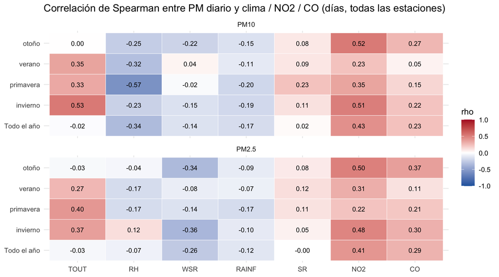

```r
vars_cor <- c("TOUT", "RH", "WSR", "RAINF", "SR", "NO2", "CO")

cor_tab <- map_dfr(c("PM25", "PM10"), \(p) map_dfr(c("Todo el año", levels(datos_dia$temporada)), \(s) {
  d <- if (s == "Todo el año") datos_dia_c else filter(datos_dia_c, temporada == s)
  tibble(contaminante = recode(p, PM25 = "PM2.5"), temporada = s, variable = vars_cor,
         rho = map_dbl(vars_cor, \(v) cor(d[[p]], d[[v]], method = "spearman", use = "pairwise.complete.obs")))
}))

cor_tab |>
  mutate(temporada = factor(temporada, c("Todo el año", "invierno", "primavera", "verano", "otoño")),
         variable = factor(variable, vars_cor)) |>
  ggplot(aes(variable, temporada, fill = rho)) +
  geom_tile(color = "white") +
  geom_text(aes(label = sprintf("%.2f", rho)), size = 3) +
  scale_fill_gradient2(limits = c(-1, 1), low = "#2166ac", mid = "white", high = "#b2182b") +
  facet_wrap(~contaminante, ncol = 1) +
  labs(x = NULL, y = NULL, fill = "rho",
       title = "Correlación de Spearman entre PM diario y clima / NO2 / CO (días, todas las estaciones)")
```

**Código**

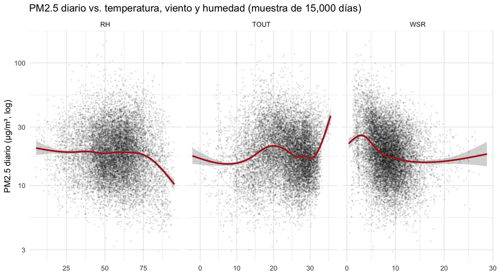

```r
datos_dia_c |>
  filter(!is.na(PM25), PM25 > 0) |>
  select(PM25, TOUT, WSR, RH) |>
  drop_na() |>
  slice_sample(n = min(15000, nrow(datos_dia_c))) |>
  pivot_longer(c(TOUT, WSR, RH), names_to = "variable", values_to = "x") |>
  ggplot(aes(x, PM25)) +
  geom_point(alpha = .08, size = .4) +
  geom_smooth(method = "gam", formula = y ~ s(x, bs = "cs"), color = "firebrick") +
  scale_y_log10() +
  facet_wrap(~variable, scales = "free_x") +
  labs(x = NULL, y = "PM2.5 diario (µg/m³, log)",
       title = "PM2.5 diario vs. temperatura, viento y humedad (muestra de 15,000 días)")
```

## 5.10 Elevación

**Código**

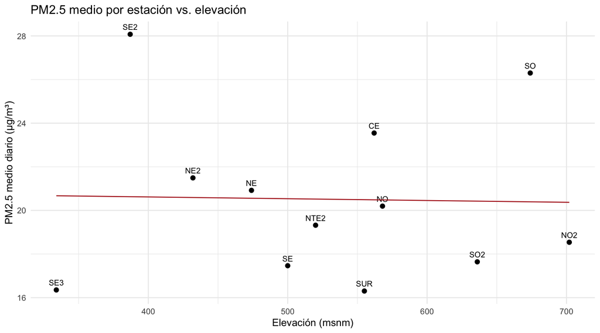

```r
ggplot(res_est, aes(msnm, `PM2.5 media`, label = estacion)) +
  geom_point(size = 2) + geom_text(vjust = -.8, size = 3) +
  geom_smooth(method = "lm", se = FALSE, color = "firebrick", linewidth = .5) +
  labs(x = "Elevación (msnm)", y = "PM2.5 medio diario (µg/m³)",
       title = "PM2.5 medio por estación vs. elevación")
```

**Código**

```r
tibble(contaminante = c("PM2.5", "PM10"),
       `rho Spearman con msnm (n = estaciones)` = c(cor(res_est$msnm, res_est$`PM2.5 media`, method = "spearman"),
                                                    cor(res_est$msnm, res_est$`PM10 media`,  method = "spearman")),
       estaciones = nrow(res_est)) |>
  kable(digits = 2)
```

| contaminante | rho Spearman con msnm (n = estaciones) | estaciones |
| --- | --- | --- |
| PM2.5 | 0.00 | 12 |
| PM10 | -0.31 | 12 |

## 5.11 Ciclo diario por temporada

**Pregunta.** ¿A qué horas se concentra el PM y cambia el patrón entre invierno y verano? Es relevante para la exposición y para interpretar el efecto de las inversiones y del tráfico.

**Código**

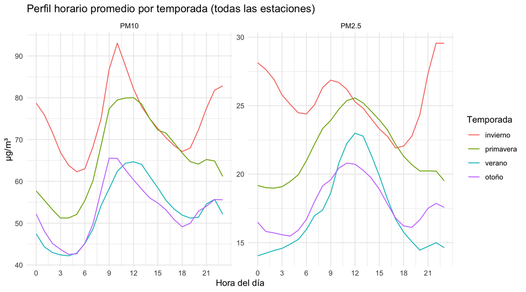

```r
datos_e2 |>
  filter(anio %in% anios_comunes) |>
  group_by(hora, temporada) |>
  summarise(PM2.5 = mean(PM25, na.rm = TRUE), PM10 = mean(PM10, na.rm = TRUE), .groups = "drop") |>
  pivot_longer(c(PM2.5, PM10), names_to = "contaminante", values_to = "media") |>
  ggplot(aes(hora, media, color = temporada)) +
  geom_line() +
  scale_x_continuous(breaks = seq(0, 23, 3)) +
  facet_wrap(~contaminante, scales = "free_y") +
  labs(x = "Hora del día", y = "µg/m³", color = "Temporada",
       title = "Perfil horario promedio por temporada (todas las estaciones)")
```

## 5.12 Tablas cruzadas

**Pregunta.** ¿Cuándo y en qué zonas se concentran las horas de calidad del aire mala, y cambia el patrón entre semana y en fin de semana? Se cruzan cuatro pares de variables: cobertura por estación y temporada (¿es comparable el perfil estacional?), calidad del aire por temporada, “Mala o peor” por zona y temporada, y mediana de PM entre semana vs. fin de semana por zona (¿pesa el tráfico y la actividad laboral?).

**Definición de “mala calidad”.** `calidad_aire` sigue el índice de la NOM-172-SEMARNAT-2019 (SEMARNAT, 2019) y describe la calidad del aire que comunica el índice al público: “Mala o peor” empieza en 45 µg/m³ de promedio móvil de 24 h. Las excedencias de la sección 5.8, en cambio, usan el límite diario de la NOM-025-SSA1 vigente cada año (33 a 45 µg/m³) sobre el promedio diario calendario (Secretaría de Salud, 2021). Son criterios distintos y no se deben mezclar en las conclusiones.

**Código**

```r
temporadas   <- c("invierno", "primavera", "verano", "otoño")
niveles_aire <- c("Buena", "Aceptable", "Mala", "Muy mala", "Extremadamente mala")
malas        <- c("Mala", "Muy mala", "Extremadamente mala")

cramer_v <- function(tab) {
  chi <- suppressWarnings(chisq.test(tab, correct = FALSE)$statistic)
  sqrt(as.numeric(chi) / (sum(tab) * (min(dim(tab)) - 1)))
}

cat_c <- cat_base |> filter(anio %in% anios_comunes)   # base horaria del periodo común
```

Cobertura por estación y temporada: (días con PM2.5 válido; perfil de fila en %).

**Código**

```r
cx_cob <- datos_dia |>
  filter(!is.na(PM25)) |>
  count(estacion, temporada) |>
  group_by(estacion) |>
  mutate(pct = n / sum(n) * 100, total = sum(n)) |>
  ungroup() |>
  select(-n) |>
  pivot_wider(names_from = temporada, values_from = pct, values_fill = 0) |>
  select(estacion, `días PM2.5` = total, all_of(temporadas)) |>
  arrange(estacion)

kable(cx_cob, digits = c(0, 0, 1, 1, 1, 1), format.args = list(big.mark = ","),
      caption = "Cobertura de PM2.5 por estación y temporada (% de los días válidos de cada estación)")
```

Cobertura de PM2.5 por estación y temporada (% de los días válidos de cada estación)

| estacion | días PM2.5 | invierno | primavera | verano | otoño |
| --- | --- | --- | --- | --- | --- |
| SUR | 1,826 | 24.7 | 25.2 | 25.2 | 24.9 |
| SE3 | 2,191 | 24.7 | 25.2 | 25.2 | 24.9 |
| SE | 1,826 | 24.7 | 25.2 | 25.2 | 24.9 |
| SO2 | 1,911 | 24.4 | 25.3 | 25.7 | 24.5 |
| NO2 | 2,187 | 24.6 | 25.2 | 25.2 | 25.0 |
| NTE2 | 2,151 | 25.0 | 24.3 | 25.3 | 25.4 |
| NO | 1,256 | 26.0 | 28.7 | 23.6 | 21.7 |
| NE | 1,485 | 24.3 | 24.8 | 26.3 | 24.6 |
| NE2 | 1,461 | 24.7 | 25.2 | 25.2 | 24.9 |
| CE | 2,179 | 24.8 | 24.8 | 25.3 | 25.1 |
| SO | 1,901 | 26.6 | 24.8 | 23.9 | 24.7 |
| SE2 | 1,826 | 24.7 | 25.2 | 25.2 | 24.9 |
| NO3 | 730 | 24.7 | 25.2 | 25.2 | 24.9 |

Calidad del aire por temporada (% de horas dentro de cada temporada).

**Código**

```r
tab_b <- table(Temporada = cat_c$temporada, Categoria = cat_c$calidad_aire)

cx_aire_temp <- as.data.frame(prop.table(tab_b, 1) * 100) |>
  pivot_wider(names_from = Categoria, values_from = Freq) |>
  select(Temporada, any_of(niveles_aire)) |>
  mutate(`Mala o peor` = rowSums(across(any_of(malas))))

kable(cx_aire_temp, digits = 2,
      caption = paste0("Categoría de calidad del aire por temporada, 2021-2023 (% de horas). V de   Cramér = ",
                       round(cramer_v(tab_b), 3)))
```

Categoría de calidad del aire por temporada, 2021-2023 (% de horas). V de Cramér = 0.164

| Temporada | Buena | Aceptable | Mala | Muy mala | Extremadamente mala | Mala o peor |
| --- | --- | --- | --- | --- | --- | --- |
| invierno | 58.69 | 33.63 | 6.85 | 0.83 | 0 | 7.68 |
| primavera | 68.75 | 28.69 | 2.54 | 0.02 | 0 | 2.56 |
| verano | 87.69 | 11.84 | 0.47 | 0.00 | 0 | 0.47 |
| otoño | 83.20 | 15.33 | 1.44 | 0.04 | 0 | 1.48 |

Horas con calidad Mala o peor, por zona y temporada (% de horas de cada celda).

**Código**

```r
cx_zona_temp <- cat_c |>
  mutate(mala_o_peor = calidad_aire %in% malas) |>
  group_by(zona, temporada) |>
  summarise(pct = mean(mala_o_peor) * 100, .groups = "drop") |>
  pivot_wider(names_from = temporada, values_from = pct) |>
  select(zona, all_of(temporadas)) |>
  left_join(distinct(cat_c, estacion, zona) |> count(zona, name = "estaciones"), by = "zona") |>
  relocate(estaciones, .after = zona)

kable(cx_zona_temp, digits = 2,
      caption = "% de horas con calidad del aire Mala o peor, por zona y temporada, 2021-2023")
```

% de horas con calidad del aire Mala o peor, por zona y temporada, 2021-2023

| zona | estaciones | invierno | primavera | verano | otoño |
| --- | --- | --- | --- | --- | --- |
| Centro | 1 | 8.47 | 7.13 | 1.43 | 0.60 |
| Noreste | 2 | 5.88 | 2.11 | 0.02 | 0.40 |
| Noroeste | 2 | 5.54 | 0.55 | 0.00 | 0.29 |
| Norte | 1 | 3.95 | 0.51 | 0.00 | 0.03 |
| Sur | 1 | 1.22 | 0.82 | 0.00 | 0.00 |
| Sureste | 3 | 10.23 | 4.45 | 1.19 | 2.94 |
| Suroeste | 2 | 12.48 | 1.80 | 0.29 | 3.45 |

Entre semana vs. fin de semana: (mediana del promedio diario, µg/m³).

**Código**

```r
cx_tipo_dia <- function(v, nombre) {
  datos_dia_c |>
    filter(!is.na(.data[[v]])) |>
    mutate(tipo = if_else(es_fin_semana, "fin", "sem")) |>
    group_by(zona, tipo) |>
    summarise(mediana = median(.data[[v]]), .groups = "drop") |>
    pivot_wider(names_from = tipo, values_from = mediana) |>
    transmute(Contaminante = nombre, Zona = zona,
              `Entre semana` = sem, `Fin de semana` = fin,
              `Cambio (%)` = (fin - sem) / sem * 100)
}

cx_finsem <- bind_rows(cx_tipo_dia("PM25", "PM2.5"), cx_tipo_dia("PM10", "PM10"))
kable(cx_finsem, digits = 1,
      caption = "Mediana del promedio diario entre semana y en fin de semana, por zona, 2021-2023")
```

Mediana del promedio diario entre semana y en fin de semana, por zona, 2021-2023

| Contaminante | Zona | Entre semana | Fin de semana | Cambio (%) |
| --- | --- | --- | --- | --- |
| PM2.5 | Centro | 21.2 | 20.7 | -2.6 |
| PM2.5 | Noreste | 19.3 | 19.5 | 0.6 |
| PM2.5 | Noroeste | 17.6 | 17.3 | -2.0 |
| PM2.5 | Norte | 18.2 | 17.2 | -5.3 |
| PM2.5 | Sur | 14.7 | 14.6 | -0.5 |
| PM2.5 | Sureste | 17.6 | 17.2 | -2.2 |
| PM2.5 | Suroeste | 19.5 | 18.4 | -6.0 |
| PM10 | Centro | 59.5 | 54.7 | -8.0 |
| PM10 | Noreste | 62.6 | 56.2 | -10.3 |
| PM10 | Noroeste | 52.3 | 47.8 | -8.7 |
| PM10 | Norte | 65.3 | 57.6 | -11.9 |
| PM10 | Sur | 46.1 | 43.0 | -6.7 |
| PM10 | Sureste | 56.0 | 52.2 | -6.7 |
| PM10 | Suroeste | 62.6 | 54.5 | -12.9 |

## 5.13 Matriz estación × mes (insumo para análisis posteriores)

Se arma y se guarda la matriz de perfiles estacionales (una fila por estación, una columna por mes y contaminante). Su tamaño recuerda una limitación: con pocas estaciones, los métodos multivariados que tratan cada estación como una observación (PCA, conglomerados) tienen **muy pocas observaciones**; la alternativa es usar estación-año-mes o estación-semana como unidad.

**Código**

```r
perfil_estacional <- sm |>
  select(estacion, mes_lab, PM25, PM10) |>
  pivot_wider(names_from = mes_lab, values_from = c(PM25, PM10), names_glue = "{.value}_{mes_lab}")
saveRDS(perfil_estacional, "salidas/etapa2_perfil_estacional.rds")

tibble(Elemento = c("Estaciones (filas)", "Variables (PM2.5 y PM10 × 12 meses)", "Celdas vacías"),
       Valor = c(nrow(perfil_estacional), ncol(perfil_estacional) - 1,
                 sum(is.na(perfil_estacional[, -1])))) |>
  kable(caption = "Dimensión de la matriz de perfiles estacionales")
```

Dimensión de la matriz de perfiles estacionales

| Elemento | Valor |
| --- | --- |
| Estaciones (filas) | 12 |
| Variables (PM2.5 y PM10 × 12 meses) | 24 |
| Celdas vacías | 0 |

## 5.14 Dependencia temporal: ¿son independientes los días y los años de una estación?

**Pregunta.** Las pruebas y modelos clásicos suponen observaciones independientes. Aquí se mide si los días consecutivos de una estación se parecen entre sí y si los años de una misma estación se parecen más entre sí que a los de otras. El resultado justifica modelar la dependencia (errores AR(1) y bootstrap por bloques; Pinheiro y Bates, 2000; Künsch, 1989) en lugar de tratar días o años como independientes.

**Paso 1. Quitar el ciclo mensual.** A cada estación se le resta la media de log(PM) de su mes; lo que queda es la variación día a día. Se completa el calendario para que los días faltantes queden como `NA` y los rezagos correspondan a días reales.

**Código**

```r
serie <- datos_dia_c |>
  mutate(estacion = droplevels(estacion)) |>
  select(estacion, dia, PM25, PM10) |>
  complete(estacion, dia = seq(min(datos_dia_c$dia), max(datos_dia_c$dia), by = "day")) |>
  arrange(estacion, dia) |>
  mutate(mes_d = month(dia)) |>
  group_by(estacion, mes_d) |>
  mutate(r25 = log(PM25) - mean(log(PM25), na.rm = TRUE),
         r10 = log(PM10) - mean(log(PM10), na.rm = TRUE)) |>
  ungroup() |>
  arrange(estacion, dia)

n_dias_est <- n_distinct(serie$dia)   # días del calendario por estación (1,095 en 2021-2023)
```

**Paso 2. Autocorrelación por estación hasta 30 días, prueba de Ljung-Box (7 rezagos) y tamaño de muestra efectivo.** Bajo un modelo AR(1), $n_{ef} = n(1-\rho_1)/(1+\rho_1)$ es el número de días independientes equivalentes.

**Código**

```r
acf_est <- serie |>
  group_by(estacion) |>
  group_modify(\(d, k) map_dfr(c(PM2.5 = "r25", PM10 = "r10"), \(v) {
    a <- acf(d[[v]], lag.max = 30, na.action = na.pass, plot = FALSE)$acf[, 1, 1]
    tibble(lag = 0:30, acf = a)
  }, .id = "contaminante")) |>
  ungroup()

lb <- serie |>
  pivot_longer(c(r25, r10), names_to = "v", values_to = "r") |>
  mutate(contaminante = if_else(v == "r25", "PM2.5", "PM10")) |>
  group_by(estacion, contaminante) |>
  summarise(n = sum(!is.na(r)),
            p_LB = Box.test(na.omit(r), lag = 7, type = "Ljung-Box")$p.value,
            .groups = "drop")

tab_acf <- acf_est |> filter(lag %in% c(1, 7)) |>
  pivot_wider(names_from = lag, values_from = acf, names_prefix = "rho_") |>
  left_join(lb, by = c("estacion", "contaminante")) |>
  mutate(n_ef = n * (1 - rho_1) / (1 + rho_1))

acf_resumen <- tab_acf |> group_by(contaminante) |>
  summarise(estaciones = n(),
            `ρ(1) mín` = min(rho_1), `ρ(1) mediana` = median(rho_1), `ρ(1) máx` = max(rho_1),
            `ρ(7) mediana` = median(rho_7), `días por estación` = median(n),
            `n efectivo (mediana)` = median(n_ef),
            `estaciones con p Ljung-Box < 0.05` = sum(p_LB < 0.05), .groups = "drop")

kable(acf_resumen, digits = 2,
      caption = "Autocorrelación de log PM diario sin ciclo mensual, 2021-2023")
```

Autocorrelación de log PM diario sin ciclo mensual, 2021-2023

| contaminante | estaciones | ρ(1) mín | ρ(1) mediana | ρ(1) máx | ρ(7) mediana | días por estación | n efectivo (mediana) | estaciones con p Ljung-Box < 0.05 |
| --- | --- | --- | --- | --- | --- | --- | --- | --- |
| PM10 | 12 | 0.49 | 0.55 | 0.58 | 0.08 | 1095 | 315.62 | 12 |
| PM2.5 | 12 | 0.44 | 0.51 | 0.70 | 0.05 | 1095 | 351.17 | 12 |

**Código**

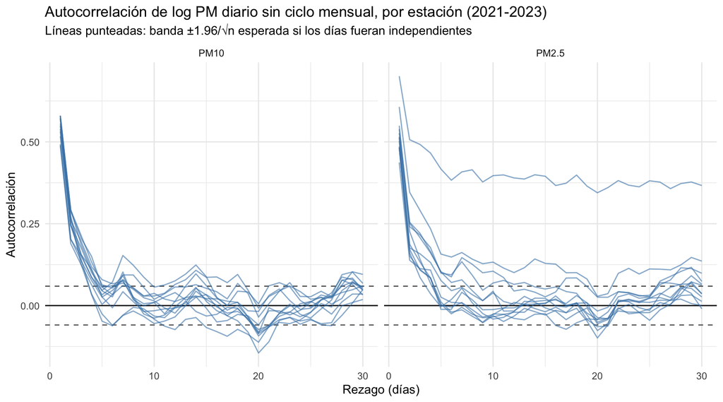

```r
g_acf <- acf_est |> filter(lag > 0) |>
  ggplot(aes(lag, acf, group = estacion)) +
  geom_hline(yintercept = 0) +
  geom_hline(yintercept = c(-1, 1) * 1.96 / sqrt(n_dias_est), linetype = 2, color = "grey40") +
  geom_line(alpha = .6, color = "steelblue") +
  facet_wrap(~contaminante) +
  labs(x = "Rezago (días)", y = "Autocorrelación",
       title = "Autocorrelación de log PM diario sin ciclo mensual, por estación (2021-2023)",
       subtitle = "Líneas punteadas: banda ±1.96/√n esperada si los días fueran independientes")
g_acf
```

**Código**

```r
ggsave("salidas/acf_pm_diario.png", g_acf, width = 6.5, height = 3, dpi = 300)
```

**Paso 3. Dependencia entre años de una misma estación.** Con los promedios anuales de 2021-2023 se calcula la correlación intraclase (ICC) de la estación (qué parte de la variación anual se debe a la estación) y la correlación de Spearman entre el primer y el último año común.

**Código**

```r
anual_c <- anual |>
  filter(anio %in% anios_comunes, !is.na(PM25), !is.na(PM10)) |>
  mutate(estacion = droplevels(factor(estacion)))

icc1 <- function(y, g) {
  a <- anova(lm(y ~ g)); msb <- a[1, "Mean Sq"]; msw <- a[2, "Mean Sq"]; k <- mean(table(g))
  (msb - msw) / (msb + (k - 1) * msw)
}
cor_anios <- function(v) {
  w <- anual_c |> select(estacion, anio, all_of(v)) |>
    pivot_wider(names_from = anio, values_from = all_of(v))
  cor(w[[as.character(min(anios_comunes))]], w[[as.character(max(anios_comunes))]],
      method = "spearman", use = "complete.obs")
}

icc_tab <- tibble(
  contaminante = c("PM2.5", "PM10"),
  `ICC de la estación (promedios anuales)` = c(icc1(log(anual_c$PM25), anual_c$estacion),
                                               icc1(log(anual_c$PM10), anual_c$estacion)),
  `ρ Spearman primer vs último año` = c(cor_anios("PM25"), cor_anios("PM10")))
kable(icc_tab, digits = 2, caption = "Dependencia entre años de una misma estación, 2021-2023")
```

Dependencia entre años de una misma estación, 2021-2023

| contaminante | ICC de la estación (promedios anuales) | ρ Spearman primer vs último año |
| --- | --- | --- |
| PM2.5 | 0.81 | 0.88 |
| PM10 | 0.75 | 0.39 |

**Lectura.** Valores de $\rho_1$ claramente por encima de la banda punteada, pruebas de Ljung-Box significativas y un $n_{ef}$ mucho menor que los días del calendario indican que los días no aportan información independiente; un ICC alto indica que los años de una misma estación no son independientes entre sí.

# 6 Síntesis de hallazgos

## 6.1 Tabla de hallazgos clave (calculada)

**Código**

```r
est_mejor <- res_est$estacion[which.min(res_est$`PM2.5 media`)]
est_peor  <- res_est$estacion[which.max(res_est$`PM2.5 media`)]
mes_tab   <- datos_dia_c |> group_by(mes_lab) |> summarise(m = mean(PM25, na.rm = TRUE))
r2_est    <- r2_tab("PM25", "PM2.5")

tibble(
  Hallazgo = c("Estación con menor PM2.5 medio", "Estación con mayor PM2.5 medio",
               "Diferencia entre ambas (µg/m³)", "Mes con mayor PM2.5 medio (todas las estaciones)",
               "Mes con menor PM2.5 medio (todas las estaciones)",
               "R² de log(PM2.5) explicado por estación", "R² explicado por mes", "R² explicado por año",
               "% de días PM2.5 sobre guía OMS (todas)", "% de días PM2.5 sobre NOM vigente (todas)"),
  Valor = c(as.character(est_mejor), as.character(est_peor),
            sprintf("%.1f", max(res_est$`PM2.5 media`) - min(res_est$`PM2.5 media`)),
            as.character(mes_tab$mes_lab[which.max(mes_tab$m)]), as.character(mes_tab$mes_lab[which.min(mes_tab$m)]),
            sprintf("%.3f", r2_est$R2[r2_est$factor == "estación"]),
            sprintf("%.3f", r2_est$R2[r2_est$factor == "mes"]),
            sprintf("%.3f", r2_est$R2[r2_est$factor == "año"]),
            sprintf("%.1f", mean(exc$e25_oms, na.rm = TRUE) * 100),
            sprintf("%.1f", mean(exc$e25_nom, na.rm = TRUE) * 100))
) |> kable(caption = "Resumen numérico para redactar la síntesis")
```

Resumen numérico para redactar la síntesis

| Hallazgo | Valor |
| --- | --- |
| Estación con menor PM2.5 medio | SUR |
| Estación con mayor PM2.5 medio | SE2 |
| Diferencia entre ambas (µg/m³) | 11.8 |
| Mes con mayor PM2.5 medio (todas las estaciones) | Dic |
| Mes con menor PM2.5 medio (todas las estaciones) | Sep |
| R² de log(PM2.5) explicado por estación | 0.115 |
| R² explicado por mes | 0.115 |
| R² explicado por año | 0.002 |
| % de días PM2.5 sobre guía OMS (todas) | 65.7 |
| % de días PM2.5 sobre NOM vigente (todas) | 4.0 |

## 6.2 Síntesis interpretativa

Las cifras provienen de las tablas y figuras de las secciones 5.1 a 5.14 (periodo común 2021-2023, 12 estaciones). Verifiquen cada una contra la salida antes de pasarla al reporte.

- **Comparabilidad.** Solo 2021-2023 tienen las 12 estaciones con cobertura completa; NO3 opera únicamente en 2024-2025 y queda fuera de las comparaciones. Se restringe al periodo común y 2020, 2024 y 2025 se usan como contexto y para validar.
- **PM2.5 y PM10.** Están correlacionadas de forma moderada (r de Pearson de 0.41 a 0.77 por estación) y ordenan distinto a las estaciones, por lo que se tratan por separado.
- **Dónde y cuándo.** La estación y el mes explican cada uno cerca de 11.5 % de la variabilidad de log PM2.5 diario (el mes explica 13.5 % en PM10), y el año prácticamente nada; la zona explica menos que la estación (3.3 %). La media de PM2.5 va de 16.3 µg/m³ (SUR) a 28.1 (SE2).
- **Forma del ciclo anual.** Es común a toda la ciudad: mínimo en septiembre y máximo en diciembre, con correlación mediana de 0.86 entre perfiles de estaciones. Las estaciones difieren sobre todo en nivel.
- **Excedencias.** Siguen el mismo calendario (diciembre-enero el peor periodo); ninguna estación cumple la guía de la OMS más de 54 % de los días.
- **Clima.** Los meses con más PM2.5 son los de menos viento y más frío; las asociaciones diarias son moderadas y la de la temperatura cambia de signo entre el año completo y las temporadas, por lo que hay que controlar estación y mes. Se llevan a modelado TOUT, RH, WSR, RAINF, SR, NO2 y CO.
- **Dependencia temporal.** Con la autocorrelación de la sección 5.14, la autocorrelación mediana de orden 1 de log PM2.5 diario sin ciclo mensual es 0.51 y el tamaño de muestra efectivo mediano es 351 días por estación frente a 1095 días del calendario; los días no pueden tratarse como independientes.
- **Cómo orienta esto el acotamiento del objetivo y los métodos de la siguiente etapa.** Se compara por estación y mes (no por zona). Los contrastes entre estaciones y meses usan un modelo lineal con errores AR(1) y bootstrap por bloques (Pinheiro y Bates, 2000; Künsch, 1989), no pruebas que permuten días libremente (como PERMANOVA). El PCA y los conglomerados se aplican a perfiles estación-mes y se validan por estabilidad y replicación en 2024-2025. Con regresión lineal múltiple y regresión logística se explican los días críticos con la meteorología.

# Referencias

Instituto Nacional de Ecología y Cambio Climático (INECC). (2015). *Evaluación de partículas suspendidas PM2.5 en el Área Metropolitana de Monterrey* (Reporte técnico). INECC.

Johnson, R. A., & Wichern, D. W. (2007). *Applied multivariate statistical analysis* (6.ª ed.). Pearson Prentice Hall.

Künsch, H. R. (1989). The jackknife and the bootstrap for general stationary observations. *The Annals of Statistics, 17*(3), 1217-1241. https://doi.org/10.1214/aos/1176347265

Molina, M., Mena, C., Mediavilla Sahagún, A., Gómes Sánchez, M. D., Barrera Huertas, H. A., García Escalante, J., Hernández Valdez, N., Sánchez Martínez, S., Castillo, J. J., & Klakamp, J. (2019). *Análisis de la contaminación por PM2.5 en la ciudad de Monterrey, Nuevo León: identificación de medidas estratégicas de control* (Environmental report). Centro Mario Molina para Estudios Estratégicos sobre Energía y Medio Ambiente A.C.

Pinheiro, J. C., & Bates, D. M. (2000). *Mixed-effects models in S and S-PLUS*. Springer. https://doi.org/10.1007/b98882

Secretaría de Medio Ambiente y Recursos Naturales (SEMARNAT). (2019). *NOM-172-SEMARNAT-2019: Lineamientos para la obtención y comunicación del Índice de Calidad del Aire y Riesgos a la Salud* (Norma Oficial Mexicana). Diario Oficial de la Federación.

Secretaría de Salud. (2021, 27 de octubre). *NOM-025-SSA1-2021, Salud ambiental. Criterio para evaluar la calidad del aire ambiente, con respecto a las partículas suspendidas PM10 y PM2.5* (Norma Oficial Mexicana). Diario Oficial de la Federación.

Sistema Integral de Monitoreo Ambiental. (2025a). *Etiquetas y descripción de variables y banderas del SIMA* [Archivo Etiquetas.xlsx].

Sistema Integral de Monitoreo Ambiental. (2025b). *Ubicación de estaciones de SIMA 2025*.

World Health Organization. (2021). *WHO global air quality guidelines: Particulate matter (PM2.5 and PM10), ozone, nitrogen dioxide, sulfur dioxide and carbon monoxide*. WHO.